# Q2: Multivariate Models

# Multivariate models

Next we created multivariate VAR models for the different time series data. Data was split into training and testing samples for three different splits, taking 171, 355, 536 days’ latest data for each time series in the test sample, and the rest first portion used for training. For VAR models, horizon of 1 was used for forecasting. File ‘calendar.csv’ was used to account for exogenous variables in each VAR model.

Process followed in each VAR model:

#### Importing libraries and creating time series objects

```r
# The libraries to be used  ##########################################################################################

library(readr)
library(urca)
library(vars)
library(mFilter)
library(tseries)
library(forecast)
library(tidyverse)
```

```r
library(ggplot2)
library(xts)
source("CustomFunctions.R")
```

```r
# Read the dataset  ########################################################################################

project_data = read.csv("Projectdata.csv")
calender = read.csv(file = 'calendar.csv',header=TRUE,sep=",")
project_data$date = as.Date(project_data$ï..date, format = "%d-%m-%y")

# Create time series objects ###############################################################################
# Time series for each variable
hobbies_ca_1_ts = xts(project_data$Hobbies_CA_1, order.by = project_data$date)
household_1_ca_1_ts = xts(project_data$Household_1_CA_1, order.by = project_data$date)
household_2_ca_1_ts = xts(project_data$Household_2_CA_1, order.by = project_data$date)
foods_1_ca_1_ts = xts(project_data$Foods_1_CA_1, order.by = project_data$date)
foods_2_ca_1_ts = xts(project_data$Foods_2_CA_1, order.by = project_data$date)
foods_3_ca_1_ts = xts(project_data$Foods_3_CA_1, order.by = project_data$date)

hobbies_ca_2_ts = xts(project_data$Hobbies_CA_2, order.by = project_data$date)
household_1_ca_2_ts = xts(project_data$Household_1_CA_2, order.by = project_data$date)
household_2_ca_2_ts = xts(project_data$Household_2_CA_2, order.by = project_data$date)
foods_1_ca_2_ts = xts(project_data$Foods_1_CA_2, order.by = project_data$date)
foods_2_ca_2_ts = xts(project_data$Foods_2_CA_2, order.by = project_data$date)
foods_3_ca_2_ts = xts(project_data$Foods_3_CA_2, order.by = project_data$date)

hobbies_ca_3_ts = xts(project_data$Hobbies_CA_3, order.by = project_data$date)
household_1_ca_3_ts = xts(project_data$Household_1_CA_3, order.by = project_data$date)
household_2_ca_3_ts = xts(project_data$Household_2_CA_3, order.by = project_data$date)
foods_1_ca_3_ts = xts(project_data$Foods_1_CA_3, order.by = project_data$date)
foods_2_ca_3_ts = xts(project_data$Foods_2_CA_3, order.by = project_data$date)
foods_3_ca_3_ts = xts(project_data$Foods_3_CA_3, order.by = project_data$date)

# Time series for aggregated variables at store level
ca_1_ts = hobbies_ca_1_ts + household_1_ca_1_ts + household_2_ca_1_ts +
  foods_1_ca_1_ts + foods_2_ca_1_ts + foods_3_ca_1_ts

ca_2_ts = hobbies_ca_2_ts + household_1_ca_2_ts + household_2_ca_2_ts +
  foods_1_ca_2_ts + foods_2_ca_2_ts + foods_3_ca_2_ts

ca_3_ts = hobbies_ca_3_ts + household_1_ca_3_ts + household_2_ca_3_ts +
  foods_1_ca_3_ts + foods_2_ca_3_ts + foods_3_ca_3_ts

# Time series for aggregated variables at product type level
hobbies_ts = hobbies_ca_1_ts + hobbies_ca_2_ts + hobbies_ca_3_ts

households_ts = household_1_ca_1_ts + household_2_ca_1_ts + household_1_ca_2_ts +
  household_2_ca_2_ts + household_1_ca_3_ts + household_2_ca_3_ts

foods_ts = foods_1_ca_1_ts + foods_2_ca_1_ts + foods_3_ca_1_ts +
  foods_1_ca_2_ts + foods_2_ca_2_ts + foods_3_ca_2_ts +
  foods_1_ca_3_ts + foods_2_ca_3_ts + foods_3_ca_3_ts

# Calender File for Exogenous Variables
calender$IsEvent[calender$event_name_1 == ""] = 0
calender$IsEvent[calender$event_name_1 != ""] = 1

cal_exog = cbind(snap_CA = calender$snap_CA, isEvent = calender$IsEvent)
```

#### Creating df to store all loss values across splits

```r
store_loss_df = data.frame(matrix(nrow = 3, ncol = 8, dimnames = list(cbind("ca_1","ca_2","ca_3"), cbind("split_1_rmsse","split_2_rmsse","split_3_rmsse","split_1_spl","split_2_spl","split_3_spl","average_RMSSE","average_SPL"))))

prod_loss_df = data.frame(matrix(nrow = 3, ncol = 8, dimnames = list(cbind("hobbies","households","foods"), cbind("split_1_rmsse","split_2_rmsse","split_3_rmsse","split_1_spl","split_2_spl","split_3_spl","average_RMSSE","average_SPL"))))

complete_loss_df = data.frame(matrix(nrow = 18, ncol = 8, dimnames = list(cbind("hobbies_ca_1","household_1_ca_1","household_2_ca_1","foods_1_ca_1","foods_2_ca_1","foods_3_ca_1","hobbies_ca_2","household_1_ca_2","household_2_ca_2","foods_1_ca_2","foods_2_ca_2","foods_3_ca_2","hobbies_ca_3","household_1_ca_3","household_2_ca_3","foods_1_ca_3","foods_2_ca_3","foods_3_ca_3"), cbind("split_1_rmsse","split_2_rmsse","split_3_rmsse","split_1_spl","split_2_spl","split_3_spl","average_RMSSE","average_SPL"))))
```

```r
# store_loss_df$split_1_rmsse=rbind(0,0,2)
store_loss_df
```

```
##      split_1_rmsse split_2_rmsse split_3_rmsse split_1_spl split_2_spl
## ca_1            NA            NA            NA          NA          NA
## ca_2            NA            NA            NA          NA          NA
## ca_3            NA            NA            NA          NA          NA
##      split_3_spl average_RMSSE average_SPL
## ca_1          NA            NA          NA
## ca_2          NA            NA          NA
## ca_3          NA            NA          NA
```

#### Creating training-testing split

Now we split our data for training and testing. We use three different splits. Models are trained and forecasts and losses are calculated for each split and stored in the results data-frame each time. This cannot be done in a loop as the step of selecting the optimum lag for VAR model requires manual checking and has not been automated in the following code. We change the value of split_n from 1 to 3 and run the whole code. Note that we also need re-run the code for creating time series objects as they have been manipulated differently for the previous split run.

```r
# Create training/testing split ######################################################################################

split_n = 3

splits = cbind(171, 355, 536)
test_days_start = splits[split_n]

test_length = test_days_start
horizon = 1

cal_exog_train = head(cal_exog, (length(cal_exog[,1])-test_days_start))
cal_exog_dumvar = head(tail(cal_exog, test_days_start), horizon)
cal_exog = cal_exog_train

# Splits for all time series
training_hobbies_ca_1_ts = head(hobbies_ca_1_ts, (length(hobbies_ca_1_ts)-test_days_start))
testing_hobbies_ca_1_ts = head(tail(hobbies_ca_1_ts, test_days_start), test_length)
hobbies_ca_1_ts = training_hobbies_ca_1_ts

training_hobbies_ca_2_ts = head(hobbies_ca_2_ts, (length(hobbies_ca_2_ts)-test_days_start))
testing_hobbies_ca_2_ts = head(tail(hobbies_ca_2_ts, test_days_start), test_length)
hobbies_ca_2_ts = training_hobbies_ca_2_ts

training_hobbies_ca_3_ts = head(hobbies_ca_3_ts, (length(hobbies_ca_3_ts)-test_days_start))
testing_hobbies_ca_3_ts = head(tail(hobbies_ca_3_ts, test_days_start), test_length)
hobbies_ca_3_ts = training_hobbies_ca_3_ts

training_household_1_ca_1_ts = head(household_1_ca_1_ts, (length(household_1_ca_1_ts)-test_days_start))
testing_household_1_ca_1_ts = head(tail(household_1_ca_1_ts, test_days_start), test_length)
household_1_ca_1_ts = training_household_1_ca_1_ts

training_household_2_ca_1_ts = head(household_2_ca_1_ts, (length(household_2_ca_1_ts)-test_days_start))
testing_household_2_ca_1_ts = head(tail(household_2_ca_1_ts, test_days_start), test_length)
household_2_ca_1_ts = training_household_2_ca_1_ts

training_household_1_ca_2_ts = head(household_1_ca_2_ts, (length(household_1_ca_2_ts)-test_days_start))
testing_household_1_ca_2_ts = head(tail(household_1_ca_2_ts, test_days_start), test_length)
household_1_ca_2_ts = training_household_1_ca_2_ts

training_household_2_ca_2_ts = head(household_2_ca_2_ts, (length(household_2_ca_2_ts)-test_days_start))
testing_household_2_ca_2_ts = head(tail(household_2_ca_2_ts, test_days_start), test_length)
household_2_ca_2_ts = training_household_2_ca_2_ts

training_household_1_ca_3_ts = head(household_1_ca_3_ts, (length(household_1_ca_3_ts)-test_days_start))
testing_household_1_ca_3_ts = head(tail(household_1_ca_3_ts, test_days_start), test_length)
household_1_ca_3_ts = training_household_1_ca_3_ts

training_household_2_ca_3_ts = head(household_2_ca_3_ts, (length(household_2_ca_3_ts)-test_days_start))
testing_household_2_ca_3_ts = head(tail(household_2_ca_3_ts, test_days_start), test_length)
household_2_ca_3_ts = training_household_2_ca_3_ts

training_foods_1_ca_1_ts = head(foods_1_ca_1_ts, (length(foods_1_ca_1_ts)-test_days_start))
testing_foods_1_ca_1_ts = head(tail(foods_1_ca_1_ts, test_days_start), test_length)
foods_1_ca_1_ts = training_foods_1_ca_1_ts

training_foods_2_ca_1_ts = head(foods_2_ca_1_ts, (length(foods_2_ca_1_ts)-test_days_start))
testing_foods_2_ca_1_ts = head(tail(foods_2_ca_1_ts, test_days_start), test_length)
foods_2_ca_1_ts = training_foods_2_ca_1_ts

training_foods_3_ca_1_ts = head(foods_3_ca_1_ts, (length(foods_3_ca_1_ts)-test_days_start))
testing_foods_3_ca_1_ts = head(tail(foods_3_ca_1_ts, test_days_start), test_length)
foods_3_ca_1_ts = training_foods_3_ca_1_ts

training_foods_1_ca_2_ts = head(foods_1_ca_2_ts, (length(foods_1_ca_2_ts)-test_days_start))
testing_foods_1_ca_2_ts = head(tail(foods_1_ca_2_ts, test_days_start), test_length)
foods_1_ca_2_ts = training_foods_1_ca_2_ts

training_foods_2_ca_2_ts = head(foods_2_ca_2_ts, (length(foods_2_ca_2_ts)-test_days_start))
testing_foods_2_ca_2_ts = head(tail(foods_2_ca_2_ts, test_days_start), test_length)
foods_2_ca_2_ts = training_foods_2_ca_2_ts

training_foods_3_ca_2_ts = head(foods_3_ca_2_ts, (length(foods_3_ca_2_ts)-test_days_start))
testing_foods_3_ca_2_ts = head(tail(foods_3_ca_2_ts, test_days_start), test_length)
foods_3_ca_2_ts = training_foods_3_ca_2_ts

training_foods_1_ca_3_ts = head(foods_1_ca_3_ts, (length(foods_1_ca_3_ts)-test_days_start))
testing_foods_1_ca_3_ts = head(tail(foods_1_ca_3_ts, test_days_start), test_length)
foods_1_ca_3_ts = training_foods_1_ca_3_ts

training_foods_2_ca_3_ts = head(foods_2_ca_3_ts, (length(foods_2_ca_3_ts)-test_days_start))
testing_foods_2_ca_3_ts = head(tail(foods_2_ca_3_ts, test_days_start), test_length)
foods_2_ca_3_ts = training_foods_2_ca_3_ts

training_foods_3_ca_3_ts = head(foods_3_ca_3_ts, (length(foods_3_ca_3_ts)-test_days_start))
testing_foods_3_ca_3_ts = head(tail(foods_3_ca_3_ts, test_days_start), test_length)
foods_3_ca_3_ts = training_foods_3_ca_3_ts


# Splits for aggregated time series
training_ca_1_ts = head(ca_1_ts, (length(ca_1_ts)-test_days_start))
testing_ca_1_ts = head(tail(ca_1_ts, test_days_start), test_length)
ca_1_ts = training_ca_1_ts

training_ca_2_ts = head(ca_2_ts, (length(ca_2_ts)-test_days_start))
testing_ca_2_ts = head(tail(ca_2_ts, test_days_start), test_length)
ca_2_ts = training_ca_2_ts

training_ca_3_ts = head(ca_3_ts, (length(ca_3_ts)-test_days_start))
testing_ca_3_ts = head(tail(ca_3_ts, test_days_start), test_length)
ca_3_ts = training_ca_3_ts



training_hobbies_ts = head(hobbies_ts, (length(hobbies_ts)-test_days_start))
testing_hobbies_ts = head(tail(hobbies_ts, test_days_start), test_length)
hobbies_ts = training_hobbies_ts

training_households_ts = head(households_ts, (length(households_ts)-test_days_start))
testing_households_ts = head(tail(households_ts, test_days_start), test_length)
households_ts = training_households_ts

training_foods_ts = head(foods_ts, (length(foods_ts)-test_days_start))
testing_foods_ts = head(tail(foods_ts, test_days_start), test_length)
foods_ts = training_foods_ts
```

## VAR model for each store

For this model, three time series were considered, one for each store CA_1, CA_2, CA_3. Each time series was created by aggregating six time series (1 hobbies, 2 households, 3 foods) for that store.

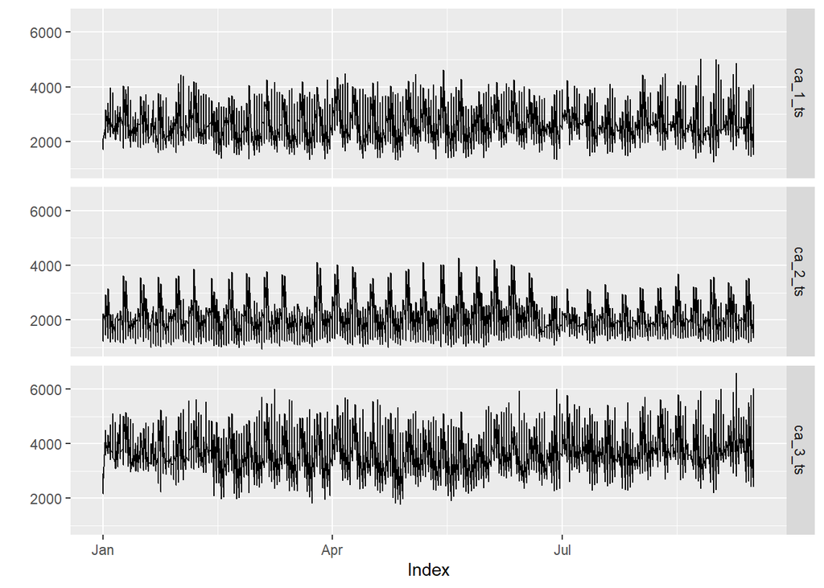

```r
# Plotting the time series for aggregated data
autoplot(cbind(ca_1_ts, ca_2_ts, ca_3_ts))
```

#### Find optimum lag to be used for creating the VAR model

```r
# Find optimum lag before running the VAR models ####################################################################
store_agg_data.bv = cbind(ca_1_ts,ca_2_ts,ca_3_ts)
lagselect = VARselect(store_agg_data.bv, lag.max = 100, type="both", exogen = cal_exog)
lagselect$selection
```

```
## AIC(n)  HQ(n)  SC(n) FPE(n)
##     42     42     16     42
```

#### Building VAR model for store level aggregated data

```r
# Building VAR model for store level aggregated data  ##############################################################
store_var = VAR(store_agg_data.bv, p = 31, type = "both", exogen = cal_exog)
summary(store_var)
```

```
##
## VAR Estimation Results:
## =========================
## Endogenous variables: ca_1_ts, ca_2_ts, ca_3_ts
## Deterministic variables: both
## Sample size: 1402
## Log Likelihood: -29481.338
## Roots of the characteristic polynomial:
## 0.9978 0.9974 0.9974 0.9963 0.9963 0.9961 0.9961 0.9955 0.9955 0.9934 0.9934 0.9927 0.9927  0.98  0.98 0.9765 0.9765 0.9699 0.9699 0.9681 0.9681 0.9629 0.9629 0.9606 0.9582 0.9582 0.957 0.957 0.9569 0.9569 0.9564 0.9564 0.9563 0.9563 0.9546 0.9546 0.9434 0.9434 0.9433 0.9433 0.9421 0.9421 0.9412 …
## Call:
## VAR(y = store_agg_data.bv, p = 31, type = "both", exogen = cal_exog)
##
##
## Estimation results for equation ca_1_ts:
## ========================================
## ca_1_ts = ca_1_ts.l1 + ca_2_ts.l1 + ca_3_ts.l1 + ca_1_ts.l2 + ca_2_ts.l2 + ca_3_ts.l2 + ca_1_ts.l3 + ca_2_ts.l3 + ca_3_ts.l3 + ca_1_ts.l4 + ca_2_ts.l4 + ca_3_ts.l4 + ca_1_ts.l5 + ca_2_ts.l5 + ca_3_ts.l5 + ca_1_ts.l6 + ca_2_ts.l6 + ca_3_ts.l6 + ca_1_ts.l7 + ca_2_ts.l7 + ca_3_ts.l7 + ca_1_ts.l8 + c…
##
##               Estimate Std. Error t value Pr(>|t|)
## ca_1_ts.l1   1.779e-01  4.666e-02   3.812 0.000144 ***
## ca_2_ts.l1  -2.575e-01  4.753e-02  -5.419 7.14e-08 ***
## ca_3_ts.l1   4.722e-03  3.703e-02   0.128 0.898548
## ca_1_ts.l2  -9.559e-03  4.692e-02  -0.204 0.838598
## ca_2_ts.l2  -1.016e-01  4.744e-02  -2.141 0.032494 *
## ca_3_ts.l2  -2.710e-04  3.696e-02  -0.007 0.994150
## ca_1_ts.l3  -5.707e-02  4.708e-02  -1.212 0.225681
## ca_2_ts.l3   3.932e-02  4.753e-02   0.827 0.408241
## ca_3_ts.l3   4.336e-02  3.702e-02   1.171 0.241615
## ca_1_ts.l4   1.026e-01  4.677e-02   2.193 0.028508 *
## ca_2_ts.l4  -2.936e-02  4.750e-02  -0.618 0.536690
## ca_3_ts.l4   9.083e-02  3.687e-02   2.463 0.013893 *
## ca_1_ts.l5   2.949e-01  4.702e-02   6.272 4.83e-10 ***
## ca_2_ts.l5   2.266e-01  4.817e-02   4.705 2.81e-06 ***
## ca_3_ts.l5   4.700e-02  3.718e-02   1.264 0.206450
## ca_1_ts.l6   2.115e-01  4.765e-02   4.439 9.80e-06 ***
## ca_2_ts.l6  -1.542e-02  4.889e-02  -0.315 0.752528
## ca_3_ts.l6   1.993e-02  3.834e-02   0.520 0.603284
## ca_1_ts.l7  -3.401e-02  4.836e-02  -0.703 0.482028
## ca_2_ts.l7   5.391e-02  5.165e-02   1.044 0.296765
## ca_3_ts.l7  -4.274e-02  3.886e-02  -1.100 0.271653
## ca_1_ts.l8  -1.736e-02  4.838e-02  -0.359 0.719758
```

[output cut: 303 more lines]

```
## F-statistic:  38.3 on 96 and 1305 DF,  p-value: < 2.2e-16
##
##
##
## Covariance matrix of residuals:
##         ca_1_ts ca_2_ts ca_3_ts
## ca_1_ts  132858   77464  115523
## ca_2_ts   77464   91699   81008
## ca_3_ts  115523   81008  178515
##
## Correlation matrix of residuals:
##         ca_1_ts ca_2_ts ca_3_ts
## ca_1_ts  1.0000  0.7018  0.7501
## ca_2_ts  0.7018  1.0000  0.6332
## ca_3_ts  0.7501  0.6332  1.0000
```

#### Granger Causality test:

```r
# Granger causality
store_var_granger_ca_1 = causality(store_var, cause = "ca_1_ts")
store_var_granger_ca_1
```

```
## $Granger
##
##  Granger causality H0: ca_1_ts do not Granger-cause ca_2_ts ca_3_ts
##
## data:  VAR object store_var
## F-Test = 3.1591, df1 = 62, df2 = 3915, p-value = 2.665e-15
##
##
## $Instant
##
##  H0: No instantaneous causality between: ca_1_ts and ca_2_ts ca_3_ts
##
## data:  VAR object store_var
## Chi-squared = 551.59, df = 2, p-value < 2.2e-16
```

```r
store_var_granger_ca_2 = causality(store_var, cause = "ca_2_ts")
store_var_granger_ca_2
```

```
## $Granger
##
##  Granger causality H0: ca_2_ts do not Granger-cause ca_1_ts ca_3_ts
##
## data:  VAR object store_var
## F-Test = 5.6554, df1 = 62, df2 = 3915, p-value < 2.2e-16
##
##
## $Instant
##
##  H0: No instantaneous causality between: ca_2_ts and ca_1_ts ca_3_ts
##
## data:  VAR object store_var
## Chi-squared = 478.77, df = 2, p-value < 2.2e-16
```

```r
store_var_granger_ca_3 = causality(store_var, cause = "ca_3_ts")
store_var_granger_ca_3
```

```
## $Granger
##
##  Granger causality H0: ca_3_ts do not Granger-cause ca_1_ts ca_2_ts
##
## data:  VAR object store_var
## F-Test = 2.8805, df1 = 62, df2 = 3915, p-value = 7.496e-13
##
##
## $Instant
##
##  H0: No instantaneous causality between: ca_3_ts and ca_1_ts ca_2_ts
##
## data:  VAR object store_var
## Chi-squared = 517.53, df = 2, p-value < 2.2e-16
```

Granger tests showed p-value < 0.05 for all three time series indicating that each granger causes the other two.

#### Making forecasts:

```r
# Forecasting  ###########
store_var_forecast = predict(store_var, n.ahead = horizon, ci = 0.95, dumvar = cal_exog_dumvar)
store_var_forecast
```

```
## $ca_1_ts
##                  fcst    lower   upper       CI
## ca_1_ts.fcst 2077.769 1363.368 2792.17 714.4008
##
## $ca_2_ts
##                 fcst    lower    upper       CI
## ca_2_ts.fcst 1862.88 1269.368 2456.393 593.5126
##
## $ca_3_ts
##                 fcst    lower    upper       CI
## ca_3_ts.fcst 3415.68 2587.576 4243.785 828.1047
```

#### Calculating RMSSE values

```r
# Finding RMSSE for comparison  ############################################################################

store_var_rmsse=cbind(ca_1=0, ca_2=0, ca_3=0)

store_var_ca_1_preds = store_var_forecast$fcst$ca_1_ts[1:horizon]
store_var_rmsse[1] = rmsse(as.numeric(testing_ca_1_ts), store_var_ca_1_preds, as.numeric(ca_1_ts))

store_var_ca_2_preds = store_var_forecast$fcst$ca_2_ts[1:horizon]
store_var_rmsse[2] = rmsse(as.numeric(testing_ca_2_ts), store_var_ca_2_preds, as.numeric(ca_2_ts))

store_var_ca_3_preds = store_var_forecast$fcst$ca_3_ts[1:horizon]
store_var_rmsse[3] = rmsse(as.numeric(testing_ca_3_ts), store_var_ca_3_preds, as.numeric(ca_3_ts))

print("RMSSE values:", quote=FALSE)
```

```
## [1] RMSSE values:
```

```r
store_var_rmsse
```

```
##        ca_1  ca_2   ca_3
## [1,] 0.3935 0.143 0.1681
```

```r
store_loss_df[, split_n]=store_var_rmsse[1,]
```

#### Finding average SPL for probabilistic forecasts

```r
# Probabilistic forecasts
cis=cbind(0.99, 0.95, 0.67, 0.5)
total_pl=cbind(ca_1=0,ca_2=0,ca_3=0)

# median case
new_forecast = predict(store_var, n.ahead = horizon, ci = 0.95, dumvar = cal_exog_dumvar)

median_preds_ca_1 = new_forecast$fcst$ca_1_ts[1:horizon]
median_preds_ca_2 = new_forecast$fcst$ca_2_ts[1:horizon]
median_preds_ca_3 = new_forecast$fcst$ca_3_ts[1:horizon]

total_pl[1] = total_pl[1] + pinball_loss(0.5,as.numeric(ca_1_ts),as.numeric(testing_ca_1_ts[1:horizon]),median_preds_ca_1,horizon)
total_pl[2] = total_pl[2] + pinball_loss(0.5,as.numeric(ca_2_ts),as.numeric(testing_ca_2_ts[1:horizon]),median_preds_ca_2,horizon)
total_pl[3] = total_pl[3] + pinball_loss(0.5,as.numeric(ca_3_ts),as.numeric(testing_ca_3_ts[1:horizon]),median_preds_ca_3,horizon)

for (i in 1:length(cis)){

  tau = (1-cis[i])/2

  new_forecast = predict(store_var, n.ahead = horizon, ci = cis[i], dumvar = cal_exog_dumvar)
  new_forecast$fcst$ca_1_ts[2:2]
  lower_preds_ca_1 = new_forecast$fcst$ca_1_ts[(horizon+1):(2*horizon)]
  upper_preds_ca_1 = new_forecast$fcst$ca_1_ts[(2*horizon+1):(3*horizon)]
  total_pl[1] = total_pl[1] + pinball_loss(tau,as.numeric(ca_1_ts),as.numeric(testing_ca_1_ts[1:horizon]),lower_preds_ca_1,horizon)
  total_pl[1] = total_pl[1] + pinball_loss(1-tau,as.numeric(ca_1_ts),as.numeric(testing_ca_1_ts[1:horizon]),upper_preds_ca_1,horizon)

  lower_preds_ca_2 = new_forecast$fcst$ca_2_ts[(horizon+1):(2*horizon)]
  upper_preds_ca_2 = new_forecast$fcst$ca_2_ts[(2*horizon+1):(3*horizon)]
  total_pl[2] = total_pl[2] + pinball_loss(tau,as.numeric(ca_2_ts),as.numeric(testing_ca_2_ts[1:horizon]),lower_preds_ca_2,horizon)
  total_pl[2] = total_pl[2] + pinball_loss(1-tau,as.numeric(ca_2_ts),as.numeric(testing_ca_2_ts[1:horizon]),upper_preds_ca_2,horizon)

  lower_preds_ca_3 = new_forecast$fcst$ca_3_ts[(horizon+1):(2*horizon)]
  upper_preds_ca_3 = new_forecast$fcst$ca_3_ts[(2*horizon+1):(3*horizon)]
  total_pl[3] = total_pl[3] + pinball_loss(tau,as.numeric(ca_3_ts),as.numeric(testing_ca_3_ts[1:horizon]),lower_preds_ca_3,horizon)
  total_pl[3] = total_pl[3] + pinball_loss(1-tau,as.numeric(ca_3_ts),as.numeric(testing_ca_3_ts[1:horizon]),upper_preds_ca_3,horizon)

}
total_pl = total_pl/((2*length(cis))+1)

print("Average SPL values:", quote=FALSE)
```

```
## [1] Average SPL values:
```

```r
print(total_pl)
```

```
##        ca_1       ca_2       ca_3
## [1,] 0.0917 0.05154444 0.05607778
```

```r
store_loss_df[, split_n+3]=total_pl[1,]
```

After running for all three splits, we calculate the average and store the results in a file as well.

```r
store_loss_df$average_RMSSE = rowMeans(store_loss_df[,c("split_1_rmsse","split_2_rmsse","split_3_rmsse")])
store_loss_df$average_SPL = rowMeans(store_loss_df[,c("split_1_spl","split_2_spl","split_3_spl")])
write.csv(store_loss_df,"Store_level_VAR_losses.csv", row.names = TRUE)
```

## VAR model for each type of products

For this model, three time series were considered, one for each product type category Hobbies, Households, Foods. Each time series was created by aggregating its corresponding time series across the three stores.

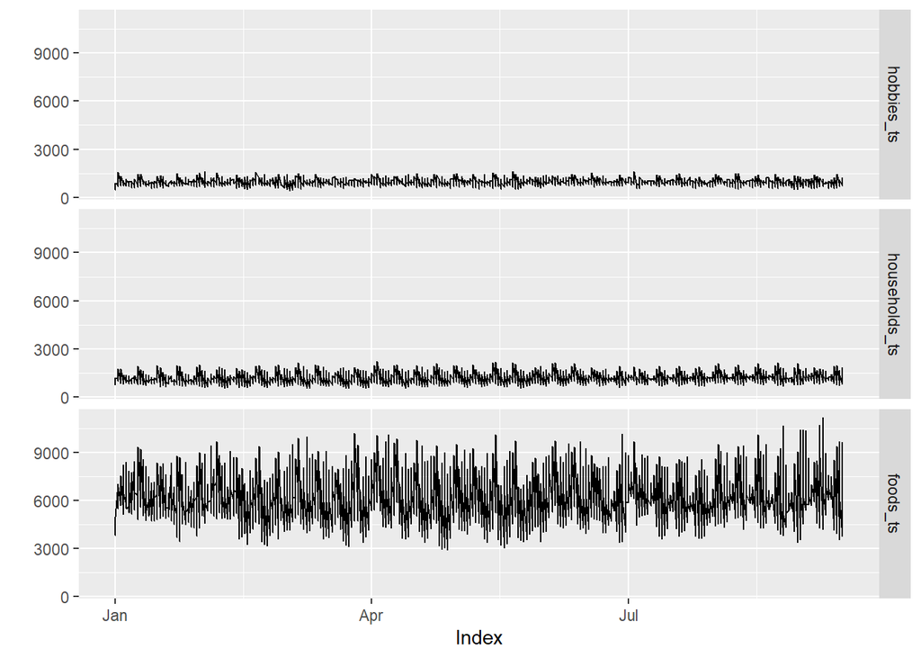

```r
# Plotting the time series for aggregated data
autoplot(cbind(hobbies_ts,households_ts,foods_ts))
```

#### Find optimum lag to be used for creating the VAR model

```r
# Find optimum lag before running the VAR models ###################################################################
prod_agg_data.bv = cbind(hobbies_ts,households_ts,foods_ts)

lagselect = VARselect(prod_agg_data.bv, lag.max = 100, type="both")
lagselect$selection
```

```
## AIC(n)  HQ(n)  SC(n) FPE(n)
##     48     42     16     48
```

#### Building VAR model for product type level aggregated data

```r
# Building VAR model for product level aggregated data  ############################################################
prod_var = VAR(prod_agg_data.bv, p = 29, type = "both", exogen = cal_exog)
summary(prod_var)
```

```
##
## VAR Estimation Results:
## =========================
## Endogenous variables: hobbies_ts, households_ts, foods_ts
## Deterministic variables: both
## Sample size: 1404
## Log Likelihood: -28321.676
## Roots of the characteristic polynomial:
## 0.9966 0.994 0.994 0.9932 0.9932 0.9925 0.9925 0.9913 0.9913 0.9905 0.9905 0.9869 0.9869 0.9749 0.9749 0.968 0.9577 0.9572 0.9572 0.956 0.956 0.9528 0.9528 0.9526 0.9526 0.9425 0.9425 0.9412 0.9412 0.9406 0.9406 0.9405 0.9405 0.9351 0.9351 0.9335 0.9335 0.9304 0.9304 0.9294 0.9294 0.9279 0.9279 0…
## Call:
## VAR(y = prod_agg_data.bv, p = 29, type = "both", exogen = cal_exog)
##
##
## Estimation results for equation hobbies_ts:
## ===========================================
## hobbies_ts = hobbies_ts.l1 + households_ts.l1 + foods_ts.l1 + hobbies_ts.l2 + households_ts.l2 + foods_ts.l2 + hobbies_ts.l3 + households_ts.l3 + foods_ts.l3 + hobbies_ts.l4 + households_ts.l4 + foods_ts.l4 + hobbies_ts.l5 + households_ts.l5 + foods_ts.l5 + hobbies_ts.l6 + households_ts.l6 + food…
##
##                     Estimate Std. Error t value Pr(>|t|)
## hobbies_ts.l1      3.369e-02  3.532e-02   0.954 0.340341
## households_ts.l1  -9.140e-02  3.883e-02  -2.354 0.018716 *
## foods_ts.l1        1.955e-02  8.008e-03   2.442 0.014750 *
## hobbies_ts.l2     -9.770e-03  3.528e-02  -0.277 0.781880
## households_ts.l2  -1.374e-01  3.902e-02  -3.521 0.000444 ***
## foods_ts.l2        1.527e-02  8.051e-03   1.897 0.058026 .
## hobbies_ts.l3     -9.547e-03  3.527e-02  -0.271 0.786691
## households_ts.l3   3.248e-02  3.896e-02   0.834 0.404485
## foods_ts.l3       -4.224e-03  8.029e-03  -0.526 0.598899
## hobbies_ts.l4     -6.683e-02  3.523e-02  -1.897 0.058098 .
## households_ts.l4  -4.915e-02  3.910e-02  -1.257 0.208879
## foods_ts.l4        1.793e-02  8.010e-03   2.238 0.025368 *
## hobbies_ts.l5      1.741e-01  3.531e-02   4.930 9.26e-07 ***
## households_ts.l5   1.064e-01  3.902e-02   2.727 0.006478 **
## foods_ts.l5        3.212e-03  7.990e-03   0.402 0.687763
## hobbies_ts.l6      1.479e-01  3.564e-02   4.149 3.55e-05 ***
## households_ts.l6   1.283e-01  4.023e-02   3.190 0.001459 **
## foods_ts.l6       -3.817e-02  8.431e-03  -4.528 6.51e-06 ***
## hobbies_ts.l7      1.200e-03  3.592e-02   0.033 0.973356
## households_ts.l7   3.909e-02  4.266e-02   0.916 0.359722
## foods_ts.l7       -1.760e-02  9.026e-03  -1.950 0.051421 .
## hobbies_ts.l8      9.590e-05  3.594e-02   0.003 0.997871
```

[output cut: 285 more lines]

```
## F-statistic: 39.25 on 90 and 1313 DF,  p-value: < 2.2e-16
##
##
##
## Covariance matrix of residuals:
##               hobbies_ts households_ts foods_ts
## hobbies_ts         18785         15318    57462
## households_ts      15318         31995   114649
## foods_ts           57462        114649   633857
##
## Correlation matrix of residuals:
##               hobbies_ts households_ts foods_ts
## hobbies_ts        1.0000        0.6248   0.5266
## households_ts     0.6248        1.0000   0.8051
## foods_ts          0.5266        0.8051   1.0000
```

#### Granger Causality test

```r
# Granger causality
prod_var_granger_hobbies = causality(prod_var, cause = "hobbies_ts")
prod_var_granger_hobbies
```

```
## $Granger
##
##  Granger causality H0: hobbies_ts do not Granger-cause households_ts
##  foods_ts
##
## data:  VAR object prod_var
## F-Test = 2.5283, df1 = 58, df2 = 3939, p-value = 2.117e-09
##
##
## $Instant
##
##  H0: No instantaneous causality between: hobbies_ts and households_ts
##  foods_ts
##
## data:  VAR object prod_var
## Chi-squared = 395.36, df = 2, p-value < 2.2e-16
```

```r
prod_var_granger_households = causality(prod_var, cause = "households_ts")
prod_var_granger_households
```

```
## $Granger
##
##  Granger causality H0: households_ts do not Granger-cause hobbies_ts
##  foods_ts
##
## data:  VAR object prod_var
## F-Test = 4.7778, df1 = 58, df2 = 3939, p-value < 2.2e-16
##
##
## $Instant
##
##  H0: No instantaneous causality between: households_ts and hobbies_ts
##  foods_ts
##
## data:  VAR object prod_var
## Chi-squared = 580.04, df = 2, p-value < 2.2e-16
```

```r
prod_var_granger_foods = causality(prod_var, cause = "foods_ts")
prod_var_granger_foods
```

```
## $Granger
##
##  Granger causality H0: foods_ts do not Granger-cause hobbies_ts
##  households_ts
##
## data:  VAR object prod_var
## F-Test = 3.9876, df1 = 58, df2 = 3939, p-value < 2.2e-16
##
##
## $Instant
##
##  H0: No instantaneous causality between: foods_ts and hobbies_ts
##  households_ts
##
## data:  VAR object prod_var
## Chi-squared = 552.6, df = 2, p-value < 2.2e-16
```

#### Making forecasts

```r
# Forecasting #################
prod_var_forecast = predict(prod_var, n.ahead = horizon, ci = 0.95, dumvar = cal_exog_dumvar)
prod_var_forecast
```

```
## $hobbies_ts
##                     fcst   lower    upper       CI
## hobbies_ts.fcst 990.3776 721.751 1259.004 268.6266
##
## $households_ts
##                        fcst    lower    upper       CI
## households_ts.fcst 1303.132 952.5501 1653.714 350.5818
##
## $foods_ts
##                   fcst    lower   upper       CI
## foods_ts.fcst 5966.622 4406.194 7527.05 1560.428
```

#### Calculating RMSSE values

```r
# Finding RMSSE for comparison  ############################################################################

prod_var_rmsse = cbind(hobbies_ts=0, households_ts=0, foods_ts=0)

prod_var_hobbies_preds = prod_var_forecast$fcst$hobbies_ts[1:horizon]
prod_var_rmsse[1] = rmsse(as.numeric(testing_hobbies_ts), prod_var_hobbies_preds, as.numeric(hobbies_ts))

prod_var_households_preds = prod_var_forecast$fcst$households_ts[1:horizon]
prod_var_rmsse[2] = rmsse(as.numeric(testing_households_ts), prod_var_households_preds, as.numeric(households_ts))

prod_var_foods_preds = prod_var_forecast$fcst$foods_ts[1:horizon]
prod_var_rmsse[3] = rmsse(as.numeric(testing_foods_ts), prod_var_foods_preds, as.numeric(foods_ts))

print("RMSSE values:", quote=FALSE)
```

```
## [1] RMSSE values:
```

```r
prod_var_rmsse
```

```
##      hobbies_ts households_ts foods_ts
## [1,]      0.005        0.0766   0.1042
```

```r
prod_loss_df[, split_n] = prod_var_rmsse[1,]
```

#### Finding average SPL for probabilistic forecasts

```r
# Probabilistic forecasts

cis=cbind(0.99, 0.95, 0.67, 0.5)
total_pl=cbind(hobbies=0,households=0,foods=0)

# median case
new_forecast = predict(prod_var, n.ahead = horizon, ci = 0.95, dumvar = cal_exog_dumvar)

median_preds_hobbies = new_forecast$fcst$hobbies_ts[1:horizon]
median_preds_households = new_forecast$fcst$households_ts[1:horizon]
median_preds_foods = new_forecast$fcst$foods_ts[1:horizon]

total_pl[1] = total_pl[1] + pinball_loss(0.5,as.numeric(hobbies_ts),as.numeric(testing_hobbies_ts[1:horizon]),median_preds_hobbies,horizon)
total_pl[2] = total_pl[2] + pinball_loss(0.5,as.numeric(households_ts),as.numeric(testing_households_ts[1:horizon]),median_preds_households,horizon)
total_pl[3] = total_pl[3] + pinball_loss(0.5,as.numeric(foods_ts),as.numeric(testing_foods_ts[1:horizon]),median_preds_foods,horizon)

for (i in 1:length(cis)){

  tau = (1-cis[i])/2

  new_forecast = predict(prod_var, n.ahead = horizon, ci = cis[i], dumvar = cal_exog_dumvar)
  new_forecast$fcst$hobbies_ts[2:2]
  lower_preds_hobbies = new_forecast$fcst$hobbies_ts[(horizon+1):(2*horizon)]
  upper_preds_hobbies = new_forecast$fcst$hobbies_ts[(2*horizon+1):(3*horizon)]
  total_pl[1] = total_pl[1] + pinball_loss(tau,as.numeric(hobbies_ts),as.numeric(testing_hobbies_ts[1:horizon]),lower_preds_hobbies,horizon)
  total_pl[1] = total_pl[1] + pinball_loss(1-tau,as.numeric(hobbies_ts),as.numeric(testing_hobbies_ts[1:horizon]),upper_preds_hobbies,horizon)

  lower_preds_households = new_forecast$fcst$households_ts[(horizon+1):(2*horizon)]
  upper_preds_households = new_forecast$fcst$households_ts[(2*horizon+1):(3*horizon)]
  total_pl[2] = total_pl[2] + pinball_loss(tau,as.numeric(households_ts),as.numeric(testing_households_ts[1:horizon]),lower_preds_households,horizon)
  total_pl[2] = total_pl[2] + pinball_loss(1-tau,as.numeric(households_ts),as.numeric(testing_households_ts[1:horizon]),upper_preds_households,horizon)

  lower_preds_foods = new_forecast$fcst$foods_ts[(horizon+1):(2*horizon)]
  upper_preds_foods = new_forecast$fcst$foods_ts[(2*horizon+1):(3*horizon)]
  total_pl[3] = total_pl[3] + pinball_loss(tau,as.numeric(foods_ts),as.numeric(testing_foods_ts[1:horizon]),lower_preds_foods,horizon)
  total_pl[3] = total_pl[3] + pinball_loss(1-tau,as.numeric(foods_ts),as.numeric(testing_foods_ts[1:horizon]),upper_preds_foods,horizon)

}
total_pl = total_pl/((2*length(cis))+1)

print("Average SPL values:", quote=FALSE)
```

```
## [1] Average SPL values:
```

```r
print(total_pl)
```

```
##         hobbies households      foods
## [1,] 0.05425556 0.05296667 0.05106667
```

```r
prod_loss_df[,split_n+3] = total_pl[1,]
```

Once model has been run for all 3 splits, we calculate average values and store results in a file

```r
prod_loss_df$average_RMSSE = rowMeans(prod_loss_df[,c("split_1_rmsse","split_2_rmsse","split_3_rmsse")])
prod_loss_df$average_SPL = rowMeans(prod_loss_df[,c("split_1_spl","split_2_spl","split_3_spl")])
write.csv(prod_loss_df,"Prod_level_VAR_losses.csv", row.names=TRUE)
```

## Large VAR model with all variables

In this model, we considered a large VAR model including all 18 time series together.

#### Find optimum lag to be used for creating the VAR model

```r
# Find optimum lag before running the Large VAR model ###############################################################

complete_data.bv = cbind(hobbies_ca_1_ts, hobbies_ca_2_ts, hobbies_ca_3_ts,
                         household_1_ca_1_ts, household_2_ca_1_ts, household_1_ca_2_ts,
                         household_2_ca_2_ts, household_1_ca_3_ts, household_2_ca_3_ts,
                         foods_1_ca_1_ts, foods_2_ca_1_ts, foods_3_ca_1_ts,
                         foods_1_ca_2_ts, foods_2_ca_2_ts, foods_3_ca_2_ts,
                         foods_1_ca_3_ts, foods_2_ca_3_ts, foods_3_ca_3_ts)

lagselect = VARselect(complete_data.bv, lag.max = 30, type="both")
lagselect$selection
```

```
## AIC(n)  HQ(n)  SC(n) FPE(n)
##     11      6      1     11
```

#### Building VAR model for complete data

```r
# Building VAR model for Large VAR model  #########################################################################
complete_var = VAR(complete_data.bv, p = 7, type = "both", exogen = cal_exog)
summary(complete_var)
```

```
##
## VAR Estimation Results:
## =========================
## Endogenous variables: hobbies_ca_1_ts, hobbies_ca_2_ts, hobbies_ca_3_ts, household_1_ca_1_ts, household_2_ca_1_ts, household_1_ca_2_ts, household_2_ca_2_ts, household_1_ca_3_ts, household_2_ca_3_ts, foods_1_ca_1_ts, foods_2_ca_1_ts, foods_3_ca_1_ts, foods_1_ca_2_ts, foods_2_ca_2_ts, foods_3_ca_2_…
## Deterministic variables: both
## Sample size: 1426
## Log Likelihood: -130480.437
## Roots of the characteristic polynomial:
## 0.981 0.9659 0.9659 0.9604 0.9604 0.9536 0.9536 0.948 0.948 0.9473 0.9473 0.9343 0.9158 0.9158 0.9151 0.9151 0.9108 0.9108 0.9047 0.8966 0.8966 0.8758 0.8758 0.8698 0.8698 0.8606 0.859 0.859 0.8486 0.8424 0.8424 0.8238 0.8185 0.8185 0.8041 0.8041 0.8002 0.8002 0.7882 0.7882 0.7855 0.7855 0.7826 0…
## Call:
## VAR(y = complete_data.bv, p = 7, type = "both", exogen = cal_exog)
##
##
## Estimation results for equation hobbies_ca_1_ts:
## ================================================
## hobbies_ca_1_ts = hobbies_ca_1_ts.l1 + hobbies_ca_2_ts.l1 + hobbies_ca_3_ts.l1 + household_1_ca_1_ts.l1 + household_2_ca_1_ts.l1 + household_1_ca_2_ts.l1 + household_2_ca_2_ts.l1 + household_1_ca_3_ts.l1 + household_2_ca_3_ts.l1 + foods_1_ca_1_ts.l1 + foods_2_ca_1_ts.l1 + foods_3_ca_1_ts.l1 + foo…
##
##                          Estimate Std. Error t value Pr(>|t|)
## hobbies_ca_1_ts.l1       0.006131   0.032854   0.187 0.851998
## hobbies_ca_2_ts.l1       0.058500   0.041632   1.405 0.160211
## hobbies_ca_3_ts.l1       0.038172   0.032378   1.179 0.238628
## household_1_ca_1_ts.l1   0.198909   0.080904   2.459 0.014078 *
## household_2_ca_1_ts.l1   0.253295   0.132157   1.917 0.055506 .
## household_1_ca_2_ts.l1  -0.156090   0.077095  -2.025 0.043108 *
## household_2_ca_2_ts.l1  -0.158012   0.095730  -1.651 0.099063 .
## household_1_ca_3_ts.l1  -0.010974   0.050562  -0.217 0.828206
## household_2_ca_3_ts.l1  -0.041955   0.086929  -0.483 0.629435
## foods_1_ca_1_ts.l1      -0.000206   0.090869  -0.002 0.998191
## foods_2_ca_1_ts.l1      -0.159559   0.054072  -2.951 0.003226 **
## foods_3_ca_1_ts.l1       0.060293   0.018225   3.308 0.000964 ***
## foods_1_ca_2_ts.l1      -0.125746   0.096085  -1.309 0.190867
## foods_2_ca_2_ts.l1      -0.260293   0.087539  -2.973 0.002999 **
## foods_3_ca_2_ts.l1       0.023273   0.024225   0.961 0.336874
## foods_1_ca_3_ts.l1      -0.146525   0.071626  -2.046 0.040988 *
## foods_2_ca_3_ts.l1       0.111138   0.034760   3.197 0.001421 **
## foods_3_ca_3_ts.l1      -0.019544   0.012391  -1.577 0.114970
## hobbies_ca_1_ts.l2       0.012283   0.032919   0.373 0.709126
## hobbies_ca_2_ts.l2      -0.019172   0.041674  -0.460 0.645554
## hobbies_ca_3_ts.l2      -0.043533   0.032547  -1.338 0.181279
## household_1_ca_1_ts.l2   0.015491   0.080632   0.192 0.847676
```

[output cut: 2782 more lines]

```
## household_1_ca_1_ts          0.4227          0.4071          0.5364
## household_2_ca_1_ts          0.3917          0.3475          0.4530
## household_1_ca_2_ts          0.3779          0.3726          0.4856
## household_2_ca_2_ts          0.3691          0.3486          0.4525
## household_1_ca_3_ts          0.4447          0.4135          0.5416
## household_2_ca_3_ts          0.3730          0.3042          0.4574
## foods_1_ca_1_ts              0.4727          0.2733          0.4111
## foods_2_ca_1_ts              0.2927          0.6111          0.5861
## foods_3_ca_1_ts              0.4320          0.5534          0.7376
## foods_1_ca_2_ts              0.3267          0.2319          0.2191
## foods_2_ca_2_ts              0.3272          0.4605          0.4511
## foods_3_ca_2_ts              0.3817          0.4868          0.5789
## foods_1_ca_3_ts              1.0000          0.2671          0.4147
## foods_2_ca_3_ts              0.2671          1.0000          0.7257
## foods_3_ca_3_ts              0.4147          0.7257          1.0000
```

#### Granger Causality test

```r
# Granger causality
complete_var_granger_hobbies_ca_1 = causality(complete_var, cause = "hobbies_ca_1_ts")
complete_var_granger_hobbies_ca_1
```

```
## $Granger
##
##  Granger causality H0: hobbies_ca_1_ts do not Granger-cause
##  hobbies_ca_2_ts hobbies_ca_3_ts household_1_ca_1_ts
##  household_2_ca_1_ts household_1_ca_2_ts household_2_ca_2_ts
##  household_1_ca_3_ts household_2_ca_3_ts foods_1_ca_1_ts
##  foods_2_ca_1_ts foods_3_ca_1_ts foods_1_ca_2_ts foods_2_ca_2_ts
##  foods_3_ca_2_ts foods_1_ca_3_ts foods_2_ca_3_ts foods_3_ca_3_ts
##
## data:  VAR object complete_var
## F-Test = 1.5183, df1 = 119, df2 = 23328, p-value = 0.0002404
##
##
## $Instant
##
##  H0: No instantaneous causality between: hobbies_ca_1_ts and
##  hobbies_ca_2_ts hobbies_ca_3_ts household_1_ca_1_ts
##  household_2_ca_1_ts household_1_ca_2_ts household_2_ca_2_ts
##  household_1_ca_3_ts household_2_ca_3_ts foods_1_ca_1_ts
##  foods_2_ca_1_ts foods_3_ca_1_ts foods_1_ca_2_ts foods_2_ca_2_ts
##  foods_3_ca_2_ts foods_1_ca_3_ts foods_2_ca_3_ts foods_3_ca_3_ts
##
## data:  VAR object complete_var
## Chi-squared = 331.58, df = 17, p-value < 2.2e-16
```

```r
complete_var_granger_hobbies_ca_2 = causality(complete_var, cause = "hobbies_ca_2_ts")
complete_var_granger_hobbies_ca_2
```

```
## $Granger
##
##  Granger causality H0: hobbies_ca_2_ts do not Granger-cause
##  hobbies_ca_1_ts hobbies_ca_3_ts household_1_ca_1_ts
##  household_2_ca_1_ts household_1_ca_2_ts household_2_ca_2_ts
##  household_1_ca_3_ts household_2_ca_3_ts foods_1_ca_1_ts
##  foods_2_ca_1_ts foods_3_ca_1_ts foods_1_ca_2_ts foods_2_ca_2_ts
##  foods_3_ca_2_ts foods_1_ca_3_ts foods_2_ca_3_ts foods_3_ca_3_ts
##
## data:  VAR object complete_var
## F-Test = 1.3938, df1 = 119, df2 = 23328, p-value = 0.003036
##
##
## $Instant
##
##  H0: No instantaneous causality between: hobbies_ca_2_ts and
##  hobbies_ca_1_ts hobbies_ca_3_ts household_1_ca_1_ts
##  household_2_ca_1_ts household_1_ca_2_ts household_2_ca_2_ts
##  household_1_ca_3_ts household_2_ca_3_ts foods_1_ca_1_ts
##  foods_2_ca_1_ts foods_3_ca_1_ts foods_1_ca_2_ts foods_2_ca_2_ts
##  foods_3_ca_2_ts foods_1_ca_3_ts foods_2_ca_3_ts foods_3_ca_3_ts
##
## data:  VAR object complete_var
## Chi-squared = 373.66, df = 17, p-value < 2.2e-16
```

```r
complete_var_granger_hobbies_ca_3 = causality(complete_var, cause = "hobbies_ca_3_ts")
complete_var_granger_hobbies_ca_3
```

```
## $Granger
##
##  Granger causality H0: hobbies_ca_3_ts do not Granger-cause
##  hobbies_ca_1_ts hobbies_ca_2_ts household_1_ca_1_ts
##  household_2_ca_1_ts household_1_ca_2_ts household_2_ca_2_ts
##  household_1_ca_3_ts household_2_ca_3_ts foods_1_ca_1_ts
##  foods_2_ca_1_ts foods_3_ca_1_ts foods_1_ca_2_ts foods_2_ca_2_ts
##  foods_3_ca_2_ts foods_1_ca_3_ts foods_2_ca_3_ts foods_3_ca_3_ts
##
## data:  VAR object complete_var
## F-Test = 1.3558, df1 = 119, df2 = 23328, p-value = 0.006079
##
##
## $Instant
##
##  H0: No instantaneous causality between: hobbies_ca_3_ts and
##  hobbies_ca_1_ts hobbies_ca_2_ts household_1_ca_1_ts
##  household_2_ca_1_ts household_1_ca_2_ts household_2_ca_2_ts
##  household_1_ca_3_ts household_2_ca_3_ts foods_1_ca_1_ts
##  foods_2_ca_1_ts foods_3_ca_1_ts foods_1_ca_2_ts foods_2_ca_2_ts
##  foods_3_ca_2_ts foods_1_ca_3_ts foods_2_ca_3_ts foods_3_ca_3_ts
##
## data:  VAR object complete_var
## Chi-squared = 289.12, df = 17, p-value < 2.2e-16
```

```r
complete_var_granger_household_1_ca_1 = causality(complete_var, cause = "household_1_ca_1_ts")
complete_var_granger_household_1_ca_1
```

```
## $Granger
##
##  Granger causality H0: household_1_ca_1_ts do not Granger-cause
##  hobbies_ca_1_ts hobbies_ca_2_ts hobbies_ca_3_ts household_2_ca_1_ts
##  household_1_ca_2_ts household_2_ca_2_ts household_1_ca_3_ts
##  household_2_ca_3_ts foods_1_ca_1_ts foods_2_ca_1_ts foods_3_ca_1_ts
##  foods_1_ca_2_ts foods_2_ca_2_ts foods_3_ca_2_ts foods_1_ca_3_ts
##  foods_2_ca_3_ts foods_3_ca_3_ts
##
## data:  VAR object complete_var
## F-Test = 1.4334, df1 = 119, df2 = 23328, p-value = 0.001413
##
##
## $Instant
##
##  H0: No instantaneous causality between: household_1_ca_1_ts and
##  hobbies_ca_1_ts hobbies_ca_2_ts hobbies_ca_3_ts household_2_ca_1_ts
##  household_1_ca_2_ts household_2_ca_2_ts household_1_ca_3_ts
##  household_2_ca_3_ts foods_1_ca_1_ts foods_2_ca_1_ts foods_3_ca_1_ts
##  foods_1_ca_2_ts foods_2_ca_2_ts foods_3_ca_2_ts foods_1_ca_3_ts
##  foods_2_ca_3_ts foods_3_ca_3_ts
##
## data:  VAR object complete_var
## Chi-squared = 571.9, df = 17, p-value < 2.2e-16
```

```r
complete_var_granger_household_2_ca_1 = causality(complete_var, cause = "household_2_ca_1_ts")
complete_var_granger_household_2_ca_1
```

```
## $Granger
##
##  Granger causality H0: household_2_ca_1_ts do not Granger-cause
##  hobbies_ca_1_ts hobbies_ca_2_ts hobbies_ca_3_ts household_1_ca_1_ts
##  household_1_ca_2_ts household_2_ca_2_ts household_1_ca_3_ts
##  household_2_ca_3_ts foods_1_ca_1_ts foods_2_ca_1_ts foods_3_ca_1_ts
##  foods_1_ca_2_ts foods_2_ca_2_ts foods_3_ca_2_ts foods_1_ca_3_ts
##  foods_2_ca_3_ts foods_3_ca_3_ts
##
## data:  VAR object complete_var
## F-Test = 1.8782, df1 = 119, df2 = 23328, p-value = 2.518e-08
##
##
## $Instant
##
##  H0: No instantaneous causality between: household_2_ca_1_ts and
##  hobbies_ca_1_ts hobbies_ca_2_ts hobbies_ca_3_ts household_1_ca_1_ts
##  household_1_ca_2_ts household_2_ca_2_ts household_1_ca_3_ts
##  household_2_ca_3_ts foods_1_ca_1_ts foods_2_ca_1_ts foods_3_ca_1_ts
##  foods_1_ca_2_ts foods_2_ca_2_ts foods_3_ca_2_ts foods_1_ca_3_ts
##  foods_2_ca_3_ts foods_3_ca_3_ts
##
## data:  VAR object complete_var
## Chi-squared = 502.57, df = 17, p-value < 2.2e-16
```

```r
complete_var_granger_household_1_ca_2 = causality(complete_var, cause = "household_1_ca_2_ts")
complete_var_granger_household_1_ca_2
```

```
## $Granger
##
##  Granger causality H0: household_1_ca_2_ts do not Granger-cause
##  hobbies_ca_1_ts hobbies_ca_2_ts hobbies_ca_3_ts household_1_ca_1_ts
##  household_2_ca_1_ts household_2_ca_2_ts household_1_ca_3_ts
##  household_2_ca_3_ts foods_1_ca_1_ts foods_2_ca_1_ts foods_3_ca_1_ts
##  foods_1_ca_2_ts foods_2_ca_2_ts foods_3_ca_2_ts foods_1_ca_3_ts
##  foods_2_ca_3_ts foods_3_ca_3_ts
##
## data:  VAR object complete_var
## F-Test = 1.8723, df1 = 119, df2 = 23328, p-value = 2.976e-08
##
##
## $Instant
##
##  H0: No instantaneous causality between: household_1_ca_2_ts and
##  hobbies_ca_1_ts hobbies_ca_2_ts hobbies_ca_3_ts household_1_ca_1_ts
##  household_2_ca_1_ts household_2_ca_2_ts household_1_ca_3_ts
##  household_2_ca_3_ts foods_1_ca_1_ts foods_2_ca_1_ts foods_3_ca_1_ts
##  foods_1_ca_2_ts foods_2_ca_2_ts foods_3_ca_2_ts foods_1_ca_3_ts
##  foods_2_ca_3_ts foods_3_ca_3_ts
##
## data:  VAR object complete_var
## Chi-squared = 598.62, df = 17, p-value < 2.2e-16
```

```r
complete_var_granger_household_2_ca_2 = causality(complete_var, cause = "household_2_ca_2_ts")
complete_var_granger_household_2_ca_2
```

```
## $Granger
##
##  Granger causality H0: household_2_ca_2_ts do not Granger-cause
##  hobbies_ca_1_ts hobbies_ca_2_ts hobbies_ca_3_ts household_1_ca_1_ts
##  household_2_ca_1_ts household_1_ca_2_ts household_1_ca_3_ts
##  household_2_ca_3_ts foods_1_ca_1_ts foods_2_ca_1_ts foods_3_ca_1_ts
##  foods_1_ca_2_ts foods_2_ca_2_ts foods_3_ca_2_ts foods_1_ca_3_ts
##  foods_2_ca_3_ts foods_3_ca_3_ts
##
## data:  VAR object complete_var
## F-Test = 1.7603, df1 = 119, df2 = 23328, p-value = 6.573e-07
##
##
## $Instant
##
##  H0: No instantaneous causality between: household_2_ca_2_ts and
##  hobbies_ca_1_ts hobbies_ca_2_ts hobbies_ca_3_ts household_1_ca_1_ts
##  household_2_ca_1_ts household_1_ca_2_ts household_1_ca_3_ts
##  household_2_ca_3_ts foods_1_ca_1_ts foods_2_ca_1_ts foods_3_ca_1_ts
##  foods_1_ca_2_ts foods_2_ca_2_ts foods_3_ca_2_ts foods_1_ca_3_ts
##  foods_2_ca_3_ts foods_3_ca_3_ts
##
## data:  VAR object complete_var
## Chi-squared = 562.94, df = 17, p-value < 2.2e-16
```

```r
complete_var_granger_household_1_ca_3 = causality(complete_var, cause = "household_1_ca_3_ts")
complete_var_granger_household_1_ca_3
```

```
## $Granger
##
##  Granger causality H0: household_1_ca_3_ts do not Granger-cause
##  hobbies_ca_1_ts hobbies_ca_2_ts hobbies_ca_3_ts household_1_ca_1_ts
##  household_2_ca_1_ts household_1_ca_2_ts household_2_ca_2_ts
##  household_2_ca_3_ts foods_1_ca_1_ts foods_2_ca_1_ts foods_3_ca_1_ts
##  foods_1_ca_2_ts foods_2_ca_2_ts foods_3_ca_2_ts foods_1_ca_3_ts
##  foods_2_ca_3_ts foods_3_ca_3_ts
##
## data:  VAR object complete_var
## F-Test = 1.7276, df1 = 119, df2 = 23328, p-value = 1.56e-06
##
##
## $Instant
##
##  H0: No instantaneous causality between: household_1_ca_3_ts and
##  hobbies_ca_1_ts hobbies_ca_2_ts hobbies_ca_3_ts household_1_ca_1_ts
##  household_2_ca_1_ts household_1_ca_2_ts household_2_ca_2_ts
##  household_2_ca_3_ts foods_1_ca_1_ts foods_2_ca_1_ts foods_3_ca_1_ts
##  foods_1_ca_2_ts foods_2_ca_2_ts foods_3_ca_2_ts foods_1_ca_3_ts
##  foods_2_ca_3_ts foods_3_ca_3_ts
##
## data:  VAR object complete_var
## Chi-squared = 515.4, df = 17, p-value < 2.2e-16
```

```r
complete_var_granger_household_2_ca_3 = causality(complete_var, cause = "household_2_ca_3_ts")
complete_var_granger_household_2_ca_3
```

```
## $Granger
##
##  Granger causality H0: household_2_ca_3_ts do not Granger-cause
##  hobbies_ca_1_ts hobbies_ca_2_ts hobbies_ca_3_ts household_1_ca_1_ts
##  household_2_ca_1_ts household_1_ca_2_ts household_2_ca_2_ts
##  household_1_ca_3_ts foods_1_ca_1_ts foods_2_ca_1_ts foods_3_ca_1_ts
##  foods_1_ca_2_ts foods_2_ca_2_ts foods_3_ca_2_ts foods_1_ca_3_ts
##  foods_2_ca_3_ts foods_3_ca_3_ts
##
## data:  VAR object complete_var
## F-Test = 1.5808, df1 = 119, df2 = 23328, p-value = 5.863e-05
##
##
## $Instant
##
##  H0: No instantaneous causality between: household_2_ca_3_ts and
##  hobbies_ca_1_ts hobbies_ca_2_ts hobbies_ca_3_ts household_1_ca_1_ts
##  household_2_ca_1_ts household_1_ca_2_ts household_2_ca_2_ts
##  household_1_ca_3_ts foods_1_ca_1_ts foods_2_ca_1_ts foods_3_ca_1_ts
##  foods_1_ca_2_ts foods_2_ca_2_ts foods_3_ca_2_ts foods_1_ca_3_ts
##  foods_2_ca_3_ts foods_3_ca_3_ts
##
## data:  VAR object complete_var
## Chi-squared = 418.88, df = 17, p-value < 2.2e-16
```

```r
complete_var_granger_foods_1_ca_1 = causality(complete_var, cause = "foods_1_ca_1_ts")
complete_var_granger_foods_1_ca_1
```

```
## $Granger
##
##  Granger causality H0: foods_1_ca_1_ts do not Granger-cause
##  hobbies_ca_1_ts hobbies_ca_2_ts hobbies_ca_3_ts household_1_ca_1_ts
##  household_2_ca_1_ts household_1_ca_2_ts household_2_ca_2_ts
##  household_1_ca_3_ts household_2_ca_3_ts foods_2_ca_1_ts
##  foods_3_ca_1_ts foods_1_ca_2_ts foods_2_ca_2_ts foods_3_ca_2_ts
##  foods_1_ca_3_ts foods_2_ca_3_ts foods_3_ca_3_ts
##
## data:  VAR object complete_var
## F-Test = 1.519, df1 = 119, df2 = 23328, p-value = 0.0002367
##
##
## $Instant
##
##  H0: No instantaneous causality between: foods_1_ca_1_ts and
##  hobbies_ca_1_ts hobbies_ca_2_ts hobbies_ca_3_ts household_1_ca_1_ts
##  household_2_ca_1_ts household_1_ca_2_ts household_2_ca_2_ts
##  household_1_ca_3_ts household_2_ca_3_ts foods_2_ca_1_ts
##  foods_3_ca_1_ts foods_1_ca_2_ts foods_2_ca_2_ts foods_3_ca_2_ts
##  foods_1_ca_3_ts foods_2_ca_3_ts foods_3_ca_3_ts
##
## data:  VAR object complete_var
## Chi-squared = 421.82, df = 17, p-value < 2.2e-16
```

```r
complete_var_granger_foods_2_ca_1 = causality(complete_var, cause = "foods_2_ca_1_ts")
complete_var_granger_foods_2_ca_1
```

```
## $Granger
##
##  Granger causality H0: foods_2_ca_1_ts do not Granger-cause
##  hobbies_ca_1_ts hobbies_ca_2_ts hobbies_ca_3_ts household_1_ca_1_ts
##  household_2_ca_1_ts household_1_ca_2_ts household_2_ca_2_ts
##  household_1_ca_3_ts household_2_ca_3_ts foods_1_ca_1_ts
##  foods_3_ca_1_ts foods_1_ca_2_ts foods_2_ca_2_ts foods_3_ca_2_ts
##  foods_1_ca_3_ts foods_2_ca_3_ts foods_3_ca_3_ts
##
## data:  VAR object complete_var
## F-Test = 1.97, df1 = 119, df2 = 23328, p-value = 1.707e-09
##
##
## $Instant
##
##  H0: No instantaneous causality between: foods_2_ca_1_ts and
##  hobbies_ca_1_ts hobbies_ca_2_ts hobbies_ca_3_ts household_1_ca_1_ts
##  household_2_ca_1_ts household_1_ca_2_ts household_2_ca_2_ts
##  household_1_ca_3_ts household_2_ca_3_ts foods_1_ca_1_ts
##  foods_3_ca_1_ts foods_1_ca_2_ts foods_2_ca_2_ts foods_3_ca_2_ts
##  foods_1_ca_3_ts foods_2_ca_3_ts foods_3_ca_3_ts
##
## data:  VAR object complete_var
## Chi-squared = 591.72, df = 17, p-value < 2.2e-16
```

```r
complete_var_granger_foods_3_ca_1 = causality(complete_var, cause = "foods_3_ca_1_ts")
complete_var_granger_foods_3_ca_1
```

```
## $Granger
##
##  Granger causality H0: foods_3_ca_1_ts do not Granger-cause
##  hobbies_ca_1_ts hobbies_ca_2_ts hobbies_ca_3_ts household_1_ca_1_ts
##  household_2_ca_1_ts household_1_ca_2_ts household_2_ca_2_ts
##  household_1_ca_3_ts household_2_ca_3_ts foods_1_ca_1_ts
##  foods_2_ca_1_ts foods_1_ca_2_ts foods_2_ca_2_ts foods_3_ca_2_ts
##  foods_1_ca_3_ts foods_2_ca_3_ts foods_3_ca_3_ts
##
## data:  VAR object complete_var
## F-Test = 1.822, df1 = 119, df2 = 23328, p-value = 1.228e-07
##
##
## $Instant
##
##  H0: No instantaneous causality between: foods_3_ca_1_ts and
##  hobbies_ca_1_ts hobbies_ca_2_ts hobbies_ca_3_ts household_1_ca_1_ts
##  household_2_ca_1_ts household_1_ca_2_ts household_2_ca_2_ts
##  household_1_ca_3_ts household_2_ca_3_ts foods_1_ca_1_ts
##  foods_2_ca_1_ts foods_1_ca_2_ts foods_2_ca_2_ts foods_3_ca_2_ts
##  foods_1_ca_3_ts foods_2_ca_3_ts foods_3_ca_3_ts
##
## data:  VAR object complete_var
## Chi-squared = 654.16, df = 17, p-value < 2.2e-16
```

```r
complete_var_granger_foods_1_ca_2 = causality(complete_var, cause = "foods_1_ca_2_ts")
complete_var_granger_foods_1_ca_2
```

```
## $Granger
##
##  Granger causality H0: foods_1_ca_2_ts do not Granger-cause
##  hobbies_ca_1_ts hobbies_ca_2_ts hobbies_ca_3_ts household_1_ca_1_ts
##  household_2_ca_1_ts household_1_ca_2_ts household_2_ca_2_ts
##  household_1_ca_3_ts household_2_ca_3_ts foods_1_ca_1_ts
##  foods_2_ca_1_ts foods_3_ca_1_ts foods_2_ca_2_ts foods_3_ca_2_ts
##  foods_1_ca_3_ts foods_2_ca_3_ts foods_3_ca_3_ts
##
## data:  VAR object complete_var
## F-Test = 3.8298, df1 = 119, df2 = 23328, p-value < 2.2e-16
##
##
## $Instant
##
##  H0: No instantaneous causality between: foods_1_ca_2_ts and
##  hobbies_ca_1_ts hobbies_ca_2_ts hobbies_ca_3_ts household_1_ca_1_ts
##  household_2_ca_1_ts household_1_ca_2_ts household_2_ca_2_ts
##  household_1_ca_3_ts household_2_ca_3_ts foods_1_ca_1_ts
##  foods_2_ca_1_ts foods_3_ca_1_ts foods_2_ca_2_ts foods_3_ca_2_ts
##  foods_1_ca_3_ts foods_2_ca_3_ts foods_3_ca_3_ts
##
## data:  VAR object complete_var
## Chi-squared = 529.83, df = 17, p-value < 2.2e-16
```

```r
complete_var_granger_foods_2_ca_2 = causality(complete_var, cause = "foods_2_ca_2_ts")
complete_var_granger_foods_2_ca_2
```

```
## $Granger
##
##  Granger causality H0: foods_2_ca_2_ts do not Granger-cause
##  hobbies_ca_1_ts hobbies_ca_2_ts hobbies_ca_3_ts household_1_ca_1_ts
##  household_2_ca_1_ts household_1_ca_2_ts household_2_ca_2_ts
##  household_1_ca_3_ts household_2_ca_3_ts foods_1_ca_1_ts
##  foods_2_ca_1_ts foods_3_ca_1_ts foods_1_ca_2_ts foods_3_ca_2_ts
##  foods_1_ca_3_ts foods_2_ca_3_ts foods_3_ca_3_ts
##
## data:  VAR object complete_var
## F-Test = 1.8693, df1 = 119, df2 = 23328, p-value = 3.245e-08
##
##
## $Instant
##
##  H0: No instantaneous causality between: foods_2_ca_2_ts and
##  hobbies_ca_1_ts hobbies_ca_2_ts hobbies_ca_3_ts household_1_ca_1_ts
##  household_2_ca_1_ts household_1_ca_2_ts household_2_ca_2_ts
##  household_1_ca_3_ts household_2_ca_3_ts foods_1_ca_1_ts
##  foods_2_ca_1_ts foods_3_ca_1_ts foods_1_ca_2_ts foods_3_ca_2_ts
##  foods_1_ca_3_ts foods_2_ca_3_ts foods_3_ca_3_ts
##
## data:  VAR object complete_var
## Chi-squared = 592.56, df = 17, p-value < 2.2e-16
```

```r
complete_var_granger_foods_3_ca_2 = causality(complete_var, cause = "foods_3_ca_2_ts")
complete_var_granger_foods_3_ca_2
```

```
## $Granger
##
##  Granger causality H0: foods_3_ca_2_ts do not Granger-cause
##  hobbies_ca_1_ts hobbies_ca_2_ts hobbies_ca_3_ts household_1_ca_1_ts
##  household_2_ca_1_ts household_1_ca_2_ts household_2_ca_2_ts
##  household_1_ca_3_ts household_2_ca_3_ts foods_1_ca_1_ts
##  foods_2_ca_1_ts foods_3_ca_1_ts foods_1_ca_2_ts foods_2_ca_2_ts
##  foods_1_ca_3_ts foods_2_ca_3_ts foods_3_ca_3_ts
##
## data:  VAR object complete_var
## F-Test = 2.2104, df1 = 119, df2 = 23328, p-value = 8.668e-13
##
##
## $Instant
##
##  H0: No instantaneous causality between: foods_3_ca_2_ts and
##  hobbies_ca_1_ts hobbies_ca_2_ts hobbies_ca_3_ts household_1_ca_1_ts
##  household_2_ca_1_ts household_1_ca_2_ts household_2_ca_2_ts
##  household_1_ca_3_ts household_2_ca_3_ts foods_1_ca_1_ts
##  foods_2_ca_1_ts foods_3_ca_1_ts foods_1_ca_2_ts foods_2_ca_2_ts
##  foods_1_ca_3_ts foods_2_ca_3_ts foods_3_ca_3_ts
##
## data:  VAR object complete_var
## Chi-squared = 659.19, df = 17, p-value < 2.2e-16
```

```r
complete_var_granger_foods_1_ca_3 = causality(complete_var, cause = "foods_1_ca_3_ts")
complete_var_granger_foods_1_ca_3
```

```
## $Granger
##
##  Granger causality H0: foods_1_ca_3_ts do not Granger-cause
##  hobbies_ca_1_ts hobbies_ca_2_ts hobbies_ca_3_ts household_1_ca_1_ts
##  household_2_ca_1_ts household_1_ca_2_ts household_2_ca_2_ts
##  household_1_ca_3_ts household_2_ca_3_ts foods_1_ca_1_ts
##  foods_2_ca_1_ts foods_3_ca_1_ts foods_1_ca_2_ts foods_2_ca_2_ts
##  foods_3_ca_2_ts foods_2_ca_3_ts foods_3_ca_3_ts
##
## data:  VAR object complete_var
## F-Test = 1.9792, df1 = 119, df2 = 23328, p-value = 1.294e-09
##
##
## $Instant
##
##  H0: No instantaneous causality between: foods_1_ca_3_ts and
##  hobbies_ca_1_ts hobbies_ca_2_ts hobbies_ca_3_ts household_1_ca_1_ts
##  household_2_ca_1_ts household_1_ca_2_ts household_2_ca_2_ts
##  household_1_ca_3_ts household_2_ca_3_ts foods_1_ca_1_ts
##  foods_2_ca_1_ts foods_3_ca_1_ts foods_1_ca_2_ts foods_2_ca_2_ts
##  foods_3_ca_2_ts foods_2_ca_3_ts foods_3_ca_3_ts
##
## data:  VAR object complete_var
## Chi-squared = 360.98, df = 17, p-value < 2.2e-16
```

```r
complete_var_granger_foods_2_ca_3 = causality(complete_var, cause = "foods_2_ca_3_ts")
complete_var_granger_foods_2_ca_3
```

```
## $Granger
##
##  Granger causality H0: foods_2_ca_3_ts do not Granger-cause
##  hobbies_ca_1_ts hobbies_ca_2_ts hobbies_ca_3_ts household_1_ca_1_ts
##  household_2_ca_1_ts household_1_ca_2_ts household_2_ca_2_ts
##  household_1_ca_3_ts household_2_ca_3_ts foods_1_ca_1_ts
##  foods_2_ca_1_ts foods_3_ca_1_ts foods_1_ca_2_ts foods_2_ca_2_ts
##  foods_3_ca_2_ts foods_1_ca_3_ts foods_3_ca_3_ts
##
## data:  VAR object complete_var
## F-Test = 2.4687, df1 = 119, df2 = 23328, p-value < 2.2e-16
##
##
## $Instant
##
##  H0: No instantaneous causality between: foods_2_ca_3_ts and
##  hobbies_ca_1_ts hobbies_ca_2_ts hobbies_ca_3_ts household_1_ca_1_ts
##  household_2_ca_1_ts household_1_ca_2_ts household_2_ca_2_ts
##  household_1_ca_3_ts household_2_ca_3_ts foods_1_ca_1_ts
##  foods_2_ca_1_ts foods_3_ca_1_ts foods_1_ca_2_ts foods_2_ca_2_ts
##  foods_3_ca_2_ts foods_1_ca_3_ts foods_3_ca_3_ts
##
## data:  VAR object complete_var
## Chi-squared = 551.23, df = 17, p-value < 2.2e-16
```

```r
complete_var_granger_foods_3_ca_3 = causality(complete_var, cause = "foods_3_ca_3_ts")
complete_var_granger_foods_3_ca_3
```

```
## $Granger
##
##  Granger causality H0: foods_3_ca_3_ts do not Granger-cause
##  hobbies_ca_1_ts hobbies_ca_2_ts hobbies_ca_3_ts household_1_ca_1_ts
##  household_2_ca_1_ts household_1_ca_2_ts household_2_ca_2_ts
##  household_1_ca_3_ts household_2_ca_3_ts foods_1_ca_1_ts
##  foods_2_ca_1_ts foods_3_ca_1_ts foods_1_ca_2_ts foods_2_ca_2_ts
##  foods_3_ca_2_ts foods_1_ca_3_ts foods_2_ca_3_ts
##
## data:  VAR object complete_var
## F-Test = 2.4593, df1 = 119, df2 = 23328, p-value = 2.22e-16
##
##
## $Instant
##
##  H0: No instantaneous causality between: foods_3_ca_3_ts and
##  hobbies_ca_1_ts hobbies_ca_2_ts hobbies_ca_3_ts household_1_ca_1_ts
##  household_2_ca_1_ts household_1_ca_2_ts household_2_ca_2_ts
##  household_1_ca_3_ts household_2_ca_3_ts foods_1_ca_1_ts
##  foods_2_ca_1_ts foods_3_ca_1_ts foods_1_ca_2_ts foods_2_ca_2_ts
##  foods_3_ca_2_ts foods_1_ca_3_ts foods_2_ca_3_ts
##
## data:  VAR object complete_var
## Chi-squared = 609.38, df = 17, p-value < 2.2e-16
```

#### Making forecasts

```r
# Forecasting ##################
complete_var_forecast = predict(complete_var, n.ahead = horizon, ci = 0.95, dumvar = cal_exog_dumvar)
complete_var_forecast
```

```
## $hobbies_ca_1_ts
##                          fcst    lower    upper       CI
## hobbies_ca_1_ts.fcst 305.8243 172.1944 439.4543 133.6299
##
## $hobbies_ca_2_ts
##                          fcst    lower    upper      CI
## hobbies_ca_2_ts.fcst 186.5016 76.32267 296.6806 110.179
##
## $hobbies_ca_3_ts
##                          fcst    lower    upper       CI
## hobbies_ca_3_ts.fcst 352.0922 220.5965 483.5878 131.4957
##
## $household_1_ca_1_ts
##                              fcst    lower    upper       CI
## household_1_ca_1_ts.fcst 193.5108 114.9328 272.0887 78.57798
##
## $household_2_ca_1_ts
##                              fcst    lower    upper       CI
## household_2_ca_1_ts.fcst 101.9043 60.62655 143.1821 41.27778
##
## $household_1_ca_2_ts
##                              fcst    lower    upper       CI
## household_1_ca_2_ts.fcst 152.1956 61.77789 242.6133 90.41772
##
## $household_2_ca_2_ts
##                              fcst    lower    upper       CI
## household_2_ca_2_ts.fcst 147.1894 82.07235 212.3065 65.11708
##
## $household_1_ca_3_ts
##                              fcst    lower    upper       CI
## household_1_ca_3_ts.fcst 393.3801 283.4885 503.2717 109.8916
##
## $household_2_ca_3_ts
##                              fcst    lower    upper       CI
## household_2_ca_3_ts.fcst 183.6136 128.3265 238.9008 55.28717
##
## $foods_1_ca_1_ts
##                          fcst    lower    upper       CI
## foods_1_ca_1_ts.fcst 123.5506 70.45163 176.6496 53.09897
##
```

[output cut: 16 more lines]

```
## $foods_3_ca_2_ts
##                          fcst    lower    upper       CI
## foods_3_ca_2_ts.fcst 965.0176 560.5875 1369.448 404.4301
##
## $foods_1_ca_3_ts
##                          fcst    lower    upper       CI
## foods_1_ca_3_ts.fcst 193.8956 130.9459 256.8453 62.94966
##
## $foods_2_ca_3_ts
##                          fcst    lower    upper       CI
## foods_2_ca_3_ts.fcst 502.5275 330.0793 674.9756 172.4481
##
## $foods_3_ca_3_ts
##                          fcst    lower    upper       CI
## foods_3_ca_3_ts.fcst 2080.597 1500.598 2660.597 579.9993
```

#### Calculating RMSSE values

```r
# Finding RMSSE for comparison  ############################################################################

complete_rmsse=cbind(hobbies_ca_1=0, household_1_ca_1=0, household_2_ca_1=0,
               foods_1_ca_1=0, foods_2_ca_1=0, foods_3_ca_1=0,
               hobbies_ca_2=0, household_1_ca_2=0, household_2_ca_2=0,
               foods_1_ca_2=0, foods_2_ca_2=0, foods_3_ca_2=0,
               hobbies_ca_3=0, household_1_ca_3=0, household_2_ca_3=0,
               foods_1_ca_3=0, foods_2_ca_3=0, foods_3_ca_3=0)

complete_var_hobbies_ca_1_preds = complete_var_forecast$fcst$hobbies_ca_1_ts[1:horizon]
complete_rmsse[1] = rmsse(as.numeric(testing_hobbies_ca_1_ts), complete_var_hobbies_ca_1_preds, as.numeric(hobbies_ca_1_ts))

complete_var_household_1_ca_1_preds = complete_var_forecast$fcst$household_1_ca_1_ts[1:horizon]
complete_rmsse[2] = rmsse(as.numeric(testing_household_1_ca_1_ts), complete_var_household_1_ca_1_preds, as.numeric(household_1_ca_1_ts))


complete_var_household_2_ca_1_preds = complete_var_forecast$fcst$household_2_ca_1_ts[1:horizon]
complete_rmsse[3] = rmsse(as.numeric(testing_household_2_ca_1_ts), complete_var_household_2_ca_1_preds, as.numeric(household_2_ca_1_ts))


complete_var_foods_1_ca_1_preds = complete_var_forecast$fcst$foods_1_ca_1_ts[1:horizon]
complete_rmsse[4] = rmsse(as.numeric(testing_foods_1_ca_1_ts), complete_var_foods_1_ca_1_preds, as.numeric(foods_1_ca_1_ts))


complete_var_foods_2_ca_1_preds = complete_var_forecast$fcst$foods_2_ca_1_ts[1:horizon]
complete_rmsse[5] = rmsse(as.numeric(testing_foods_2_ca_1_ts), complete_var_foods_2_ca_1_preds, as.numeric(foods_2_ca_1_ts))


complete_var_foods_3_ca_1_preds = complete_var_forecast$fcst$foods_3_ca_1_ts[1:horizon]
complete_rmsse[6] = rmsse(as.numeric(testing_foods_3_ca_1_ts), complete_var_foods_3_ca_1_preds, as.numeric(foods_3_ca_1_ts))





complete_var_hobbies_ca_2_preds = complete_var_forecast$fcst$hobbies_ca_2_ts[1:horizon]
complete_rmsse[7] = rmsse(as.numeric(testing_hobbies_ca_2_ts), complete_var_hobbies_ca_2_preds, as.numeric(hobbies_ca_2_ts))


complete_var_household_1_ca_2_preds = complete_var_forecast$fcst$household_1_ca_2_ts[1:horizon]
complete_rmsse[8] = rmsse(as.numeric(testing_household_1_ca_2_ts), complete_var_household_1_ca_2_preds, as.numeric(household_1_ca_2_ts))


complete_var_household_2_ca_2_preds = complete_var_forecast$fcst$household_2_ca_2_ts[1:horizon]
complete_rmsse[9] = rmsse(as.numeric(testing_household_2_ca_2_ts), complete_var_household_2_ca_2_preds, as.numeric(household_2_ca_2_ts))


complete_var_foods_1_ca_2_preds = complete_var_forecast$fcst$foods_1_ca_2_ts[1:horizon]
complete_rmsse[10] = rmsse(as.numeric(testing_foods_1_ca_2_ts), complete_var_foods_1_ca_2_preds, as.numeric(foods_1_ca_2_ts))


complete_var_foods_2_ca_2_preds = complete_var_forecast$fcst$foods_2_ca_2_ts[1:horizon]
complete_rmsse[11] = rmsse(as.numeric(testing_foods_2_ca_2_ts), complete_var_foods_2_ca_2_preds, as.numeric(foods_2_ca_2_ts))


complete_var_foods_3_ca_2_preds = complete_var_forecast$fcst$foods_3_ca_2_ts[1:horizon]
complete_rmsse[12] = rmsse(as.numeric(testing_foods_3_ca_2_ts), complete_var_foods_3_ca_2_preds, as.numeric(foods_3_ca_2_ts))





complete_var_hobbies_ca_3_preds = complete_var_forecast$fcst$hobbies_ca_3_ts[1:horizon]
complete_rmsse[13] = rmsse(as.numeric(testing_hobbies_ca_3_ts), complete_var_hobbies_ca_3_preds, as.numeric(hobbies_ca_3_ts))


complete_var_household_1_ca_3_preds = complete_var_forecast$fcst$household_1_ca_3_ts[1:horizon]
complete_rmsse[14] = rmsse(as.numeric(testing_household_1_ca_3_ts), complete_var_household_1_ca_3_preds, as.numeric(household_1_ca_3_ts))


complete_var_household_2_ca_3_preds = complete_var_forecast$fcst$household_2_ca_3_ts[1:horizon]
complete_rmsse[15] = rmsse(as.numeric(testing_household_2_ca_3_ts), complete_var_household_2_ca_3_preds, as.numeric(household_2_ca_3_ts))


complete_var_foods_1_ca_3_preds = complete_var_forecast$fcst$foods_1_ca_3_ts[1:horizon]
complete_rmsse[16] = rmsse(as.numeric(testing_foods_1_ca_3_ts), complete_var_foods_1_ca_3_preds, as.numeric(foods_1_ca_3_ts))


complete_var_foods_2_ca_3_preds = complete_var_forecast$fcst$foods_2_ca_3_ts[1:horizon]
complete_rmsse[17] = rmsse(as.numeric(testing_foods_2_ca_3_ts), complete_var_foods_2_ca_3_preds, as.numeric(foods_2_ca_3_ts))


complete_var_foods_3_ca_3_preds = complete_var_forecast$fcst$foods_3_ca_3_ts[1:horizon]
complete_rmsse[18] = rmsse(as.numeric(testing_foods_3_ca_3_ts), complete_var_foods_3_ca_3_preds, as.numeric(foods_3_ca_3_ts))

print("RMSSE values:", quote=FALSE)
```

```
## [1] RMSSE values:
```

```r
complete_rmsse
```

```
##      hobbies_ca_1 household_1_ca_1 household_2_ca_1 foods_1_ca_1 foods_2_ca_1
## [1,]       0.3761           0.4422           0.0024       0.3562       0.0646
##      foods_3_ca_1 hobbies_ca_2 household_1_ca_2 household_2_ca_2 foods_1_ca_2
## [1,]       0.0359        0.314           0.4083           0.2187       0.2817
##      foods_2_ca_2 foods_3_ca_2 hobbies_ca_3 household_1_ca_3 household_2_ca_3
## [1,]       0.3293       0.3337       0.5566           0.2128           0.0074
##      foods_1_ca_3 foods_2_ca_3 foods_3_ca_3
## [1,]       0.0364       0.4865       0.1546
```

```r
complete_loss_df[, split_n]=complete_rmsse[1,]
```

#### Finding average SPL for probabilistic forecasts

```r
# Probabilistic forecasts

cis=cbind(0.99, 0.95, 0.67, 0.5)
total_pl=cbind(hobbies_ca_1=0, household_1_ca_1=0, household_2_ca_1=0,
               foods_1_ca_1=0, foods_2_ca_1=0, foods_3_ca_1=0,
               hobbies_ca_2=0, household_1_ca_2=0, household_2_ca_2=0,
               foods_1_ca_2=0, foods_2_ca_2=0, foods_3_ca_2=0,
               hobbies_ca_3=0, household_1_ca_3=0, household_2_ca_3=0,
               foods_1_ca_3=0, foods_2_ca_3=0, foods_3_ca_3=0)

# median case
new_forecast = predict(complete_var, n.ahead = horizon, ci = 0.95, dumvar = cal_exog_dumvar)

median_preds_hobbies_ca_1 = new_forecast$fcst$hobbies_ca_1_ts[1:horizon]
median_preds_household_1_ca_1 = new_forecast$fcst$household_1_ca_1_ts[1:horizon]
median_preds_household_2_ca_1 = new_forecast$fcst$household_2_ca_1_ts[1:horizon]
median_preds_foods_1_ca_1 = new_forecast$fcst$foods_1_ca_1_ts[1:horizon]
median_preds_foods_2_ca_1 = new_forecast$fcst$foods_2_ca_1_ts[1:horizon]
median_preds_foods_3_ca_1 = new_forecast$fcst$foods_3_ca_1_ts[1:horizon]

median_preds_hobbies_ca_2 = new_forecast$fcst$hobbies_ca_2_ts[1:horizon]
median_preds_household_1_ca_2 = new_forecast$fcst$household_1_ca_2_ts[1:horizon]
median_preds_household_2_ca_2 = new_forecast$fcst$household_2_ca_2_ts[1:horizon]
median_preds_foods_1_ca_2 = new_forecast$fcst$foods_1_ca_2_ts[1:horizon]
median_preds_foods_2_ca_2 = new_forecast$fcst$foods_2_ca_2_ts[1:horizon]
median_preds_foods_3_ca_2 = new_forecast$fcst$foods_3_ca_2_ts[1:horizon]

median_preds_hobbies_ca_3 = new_forecast$fcst$hobbies_ca_3_ts[1:horizon]
median_preds_household_1_ca_3 = new_forecast$fcst$household_1_ca_3_ts[1:horizon]
median_preds_household_2_ca_3 = new_forecast$fcst$household_2_ca_3_ts[1:horizon]
median_preds_foods_1_ca_3 = new_forecast$fcst$foods_1_ca_3_ts[1:horizon]
median_preds_foods_2_ca_3 = new_forecast$fcst$foods_2_ca_3_ts[1:horizon]
median_preds_foods_3_ca_3 = new_forecast$fcst$foods_3_ca_3_ts[1:horizon]

total_pl[1] = total_pl[1] + pinball_loss(0.5,as.numeric(hobbies_ca_1_ts),as.numeric(testing_hobbies_ca_1_ts[1:horizon]),median_preds_hobbies_ca_1,horizon)
total_pl[2] = total_pl[2] + pinball_loss(0.5,as.numeric(household_1_ca_1_ts),as.numeric(testing_household_1_ca_1_ts[1:horizon]),median_preds_household_1_ca_1,horizon)
total_pl[3] = total_pl[3] + pinball_loss(0.5,as.numeric(household_2_ca_1_ts),as.numeric(testing_household_2_ca_1_ts[1:horizon]),median_preds_household_2_ca_1,horizon)
total_pl[4] = total_pl[4] + pinball_loss(0.5,as.numeric(foods_1_ca_1_ts),as.numeric(testing_foods_1_ca_1_ts[1:horizon]),median_preds_foods_1_ca_1,horizon)
total_pl[5] = total_pl[5] + pinball_loss(0.5,as.numeric(foods_2_ca_1_ts),as.numeric(testing_foods_2_ca_1_ts[1:horizon]),median_preds_foods_2_ca_1,horizon)
total_pl[6] = total_pl[6] + pinball_loss(0.5,as.numeric(foods_3_ca_1_ts),as.numeric(testing_foods_3_ca_1_ts[1:horizon]),median_preds_foods_3_ca_1,horizon)

total_pl[7] = total_pl[7] + pinball_loss(0.5,as.numeric(hobbies_ca_2_ts),as.numeric(testing_hobbies_ca_2_ts[1:horizon]),median_preds_hobbies_ca_2,horizon)
total_pl[8] = total_pl[8] + pinball_loss(0.5,as.numeric(household_1_ca_2_ts),as.numeric(testing_household_1_ca_2_ts[1:horizon]),median_preds_household_1_ca_2,horizon)
total_pl[9] = total_pl[9] + pinball_loss(0.5,as.numeric(household_2_ca_2_ts),as.numeric(testing_household_2_ca_2_ts[1:horizon]),median_preds_household_2_ca_2,horizon)
total_pl[10] = total_pl[10] + pinball_loss(0.5,as.numeric(foods_1_ca_2_ts),as.numeric(testing_foods_1_ca_2_ts[1:horizon]),median_preds_foods_1_ca_2,horizon)
total_pl[11] = total_pl[11] + pinball_loss(0.5,as.numeric(foods_2_ca_2_ts),as.numeric(testing_foods_2_ca_2_ts[1:horizon]),median_preds_foods_2_ca_2,horizon)
total_pl[12] = total_pl[12] + pinball_loss(0.5,as.numeric(foods_3_ca_2_ts),as.numeric(testing_foods_3_ca_2_ts[1:horizon]),median_preds_foods_3_ca_2,horizon)

total_pl[13] = total_pl[13] + pinball_loss(0.5,as.numeric(hobbies_ca_3_ts),as.numeric(testing_hobbies_ca_3_ts[1:horizon]),median_preds_hobbies_ca_3,horizon)
total_pl[14] = total_pl[14] + pinball_loss(0.5,as.numeric(household_1_ca_3_ts),as.numeric(testing_household_1_ca_3_ts[1:horizon]),median_preds_household_1_ca_3,horizon)
total_pl[15] = total_pl[15] + pinball_loss(0.5,as.numeric(household_2_ca_3_ts),as.numeric(testing_household_2_ca_3_ts[1:horizon]),median_preds_household_2_ca_3,horizon)
total_pl[16] = total_pl[16] + pinball_loss(0.5,as.numeric(foods_1_ca_3_ts),as.numeric(testing_foods_1_ca_3_ts[1:horizon]),median_preds_foods_1_ca_3,horizon)
total_pl[17] = total_pl[17] + pinball_loss(0.5,as.numeric(foods_2_ca_3_ts),as.numeric(testing_foods_2_ca_3_ts[1:horizon]),median_preds_foods_2_ca_3,horizon)
total_pl[18] = total_pl[18] + pinball_loss(0.5,as.numeric(foods_3_ca_3_ts),as.numeric(testing_foods_3_ca_3_ts[1:horizon]),median_preds_foods_3_ca_3,horizon)

for (i in 1:length(cis)){

  tau = (1-cis[i])/2

  new_forecast = predict(complete_var, n.ahead = horizon, ci = cis[i], dumvar = cal_exog_dumvar)

  lower_preds_hobbies_ca_1_ts = new_forecast$fcst$hobbies_ca_1_ts[(horizon+1):(2*horizon)]
  upper_preds_hobbies_ca_1_ts = new_forecast$fcst$hobbies_ca_1_ts[(2*horizon+1):(3*horizon)]
  total_pl[1] = total_pl[1] + pinball_loss(tau,as.numeric(hobbies_ca_1_ts),as.numeric(testing_hobbies_ca_1_ts[1:horizon]),lower_preds_hobbies_ca_1_ts,horizon)
  total_pl[1] = total_pl[1] + pinball_loss(1-tau,as.numeric(hobbies_ca_1_ts),as.numeric(testing_hobbies_ca_1_ts[1:horizon]),upper_preds_hobbies_ca_1_ts,horizon)

  lower_preds_household_1_ca_1 = new_forecast$fcst$household_1_ca_1_ts[(horizon+1):(2*horizon)]
  upper_preds_household_1_ca_1 = new_forecast$fcst$household_1_ca_1_ts[(2*horizon+1):(3*horizon)]
  total_pl[2] = total_pl[2] + pinball_loss(tau,as.numeric(household_1_ca_1_ts),as.numeric(testing_household_1_ca_1_ts[1:horizon]),lower_preds_household_1_ca_1,horizon)
  total_pl[2] = total_pl[2] + pinball_loss(1-tau,as.numeric(household_1_ca_1_ts),as.numeric(testing_household_1_ca_1_ts[1:horizon]),upper_preds_household_1_ca_1,horizon)
```

```r
  lower_preds_household_2_ca_1 = new_forecast$fcst$household_2_ca_1_ts[(horizon+1):(2*horizon)]
  upper_preds_household_2_ca_1 = new_forecast$fcst$household_2_ca_1_ts[(2*horizon+1):(3*horizon)]
  total_pl[3] = total_pl[3] + pinball_loss(tau,as.numeric(household_2_ca_1_ts),as.numeric(testing_household_2_ca_1_ts[1:horizon]),lower_preds_household_2_ca_1,horizon)
  total_pl[3] = total_pl[3] + pinball_loss(1-tau,as.numeric(household_2_ca_1_ts),as.numeric(testing_household_2_ca_1_ts[1:horizon]),upper_preds_household_2_ca_1,horizon)

  lower_preds_foods_1_ca_1 = new_forecast$fcst$foods_1_ca_1_ts[(horizon+1):(2*horizon)]
  upper_preds_foods_1_ca_1 = new_forecast$fcst$foods_1_ca_1_ts[(2*horizon+1):(3*horizon)]
  total_pl[4] = total_pl[4] + pinball_loss(tau,as.numeric(foods_1_ca_1_ts),as.numeric(testing_foods_1_ca_1_ts[1:horizon]),lower_preds_foods_1_ca_1,horizon)
  total_pl[4] = total_pl[4] + pinball_loss(1-tau,as.numeric(foods_1_ca_1_ts),as.numeric(testing_foods_1_ca_1_ts[1:horizon]),upper_preds_foods_1_ca_1,horizon)

  lower_preds_foods_2_ca_1 = new_forecast$fcst$foods_2_ca_1_ts[(horizon+1):(2*horizon)]
  upper_preds_foods_2_ca_1 = new_forecast$fcst$foods_2_ca_1_ts[(2*horizon+1):(3*horizon)]
  total_pl[5] = total_pl[5] + pinball_loss(tau,as.numeric(foods_2_ca_1_ts),as.numeric(testing_foods_2_ca_1_ts[1:horizon]),lower_preds_foods_2_ca_1,horizon)
  total_pl[5] = total_pl[5] + pinball_loss(1-tau,as.numeric(foods_2_ca_1_ts),as.numeric(testing_foods_2_ca_1_ts[1:horizon]),upper_preds_foods_2_ca_1,horizon)

  lower_preds_foods_3_ca_1 = new_forecast$fcst$foods_3_ca_1_ts[(horizon+1):(2*horizon)]
  upper_preds_foods_3_ca_1 = new_forecast$fcst$foods_3_ca_1_ts[(2*horizon+1):(3*horizon)]
  total_pl[6] = total_pl[6] + pinball_loss(tau,as.numeric(foods_3_ca_1_ts),as.numeric(testing_foods_3_ca_1_ts[1:horizon]),lower_preds_foods_3_ca_1,horizon)
  total_pl[6] = total_pl[6] + pinball_loss(1-tau,as.numeric(foods_3_ca_1_ts),as.numeric(testing_foods_3_ca_1_ts[1:horizon]),upper_preds_foods_3_ca_1,horizon)



  lower_preds_hobbies_ca_2_ts = new_forecast$fcst$hobbies_ca_2_ts[(horizon+1):(2*horizon)]
  upper_preds_hobbies_ca_2_ts = new_forecast$fcst$hobbies_ca_2_ts[(2*horizon+1):(3*horizon)]
  total_pl[7] = total_pl[7] + pinball_loss(tau,as.numeric(hobbies_ca_2_ts),as.numeric(testing_hobbies_ca_2_ts[1:horizon]),lower_preds_hobbies_ca_2_ts,horizon)
  total_pl[7] = total_pl[7] + pinball_loss(1-tau,as.numeric(hobbies_ca_2_ts),as.numeric(testing_hobbies_ca_2_ts[1:horizon]),upper_preds_hobbies_ca_2_ts,horizon)

  lower_preds_household_1_ca_2 = new_forecast$fcst$household_1_ca_2_ts[(horizon+1):(2*horizon)]
  upper_preds_household_1_ca_2 = new_forecast$fcst$household_1_ca_2_ts[(2*horizon+1):(3*horizon)]
  total_pl[8] = total_pl[8] + pinball_loss(tau,as.numeric(household_1_ca_2_ts),as.numeric(testing_household_1_ca_2_ts[1:horizon]),lower_preds_household_1_ca_2,horizon)
  total_pl[8] = total_pl[8] + pinball_loss(1-tau,as.numeric(household_1_ca_2_ts),as.numeric(testing_household_1_ca_2_ts[1:horizon]),upper_preds_household_1_ca_2,horizon)

  lower_preds_household_2_ca_2 = new_forecast$fcst$household_2_ca_2_ts[(horizon+1):(2*horizon)]
  upper_preds_household_2_ca_2 = new_forecast$fcst$household_2_ca_2_ts[(2*horizon+1):(3*horizon)]
  total_pl[9] = total_pl[9] + pinball_loss(tau,as.numeric(household_2_ca_2_ts),as.numeric(testing_household_2_ca_2_ts[1:horizon]),lower_preds_household_2_ca_2,horizon)
  total_pl[9] = total_pl[9] + pinball_loss(1-tau,as.numeric(household_2_ca_2_ts),as.numeric(testing_household_2_ca_2_ts[1:horizon]),upper_preds_household_2_ca_2,horizon)

  lower_preds_foods_1_ca_2 = new_forecast$fcst$foods_1_ca_2_ts[(horizon+1):(2*horizon)]
  upper_preds_foods_1_ca_2 = new_forecast$fcst$foods_1_ca_2_ts[(2*horizon+1):(3*horizon)]
  total_pl[10] = total_pl[10] + pinball_loss(tau,as.numeric(foods_1_ca_2_ts),as.numeric(testing_foods_1_ca_2_ts[1:horizon]),lower_preds_foods_1_ca_2,horizon)
  total_pl[10] = total_pl[10] + pinball_loss(1-tau,as.numeric(foods_1_ca_2_ts),as.numeric(testing_foods_1_ca_2_ts[1:horizon]),upper_preds_foods_1_ca_2,horizon)

  lower_preds_foods_2_ca_2 = new_forecast$fcst$foods_2_ca_2_ts[(horizon+1):(2*horizon)]
  upper_preds_foods_2_ca_2 = new_forecast$fcst$foods_2_ca_2_ts[(2*horizon+1):(3*horizon)]
  total_pl[11] = total_pl[11] + pinball_loss(tau,as.numeric(foods_2_ca_2_ts),as.numeric(testing_foods_2_ca_2_ts[1:horizon]),lower_preds_foods_2_ca_2,horizon)
  total_pl[11] = total_pl[11] + pinball_loss(1-tau,as.numeric(foods_2_ca_2_ts),as.numeric(testing_foods_2_ca_2_ts[1:horizon]),upper_preds_foods_2_ca_2,horizon)

  lower_preds_foods_3_ca_2 = new_forecast$fcst$foods_3_ca_2_ts[(horizon+1):(2*horizon)]
  upper_preds_foods_3_ca_2 = new_forecast$fcst$foods_3_ca_2_ts[(2*horizon+1):(3*horizon)]
  total_pl[12] = total_pl[12] + pinball_loss(tau,as.numeric(foods_3_ca_2_ts),as.numeric(testing_foods_3_ca_2_ts[1:horizon]),lower_preds_foods_3_ca_2,horizon)
  total_pl[12] = total_pl[12] + pinball_loss(1-tau,as.numeric(foods_3_ca_2_ts),as.numeric(testing_foods_3_ca_2_ts[1:horizon]),upper_preds_foods_3_ca_2,horizon)




  lower_preds_hobbies_ca_3_ts = new_forecast$fcst$hobbies_ca_3_ts[(horizon+1):(2*horizon)]
  upper_preds_hobbies_ca_3_ts = new_forecast$fcst$hobbies_ca_3_ts[(2*horizon+1):(3*horizon)]
  total_pl[13] = total_pl[13] + pinball_loss(tau,as.numeric(hobbies_ca_3_ts),as.numeric(testing_hobbies_ca_3_ts[1:horizon]),lower_preds_hobbies_ca_3_ts,horizon)
  total_pl[13] = total_pl[13] + pinball_loss(1-tau,as.numeric(hobbies_ca_3_ts),as.numeric(testing_hobbies_ca_3_ts[1:horizon]),upper_preds_hobbies_ca_3_ts,horizon)

  lower_preds_household_1_ca_3 = new_forecast$fcst$household_1_ca_3_ts[(horizon+1):(2*horizon)]
  upper_preds_household_1_ca_3 = new_forecast$fcst$household_1_ca_3_ts[(2*horizon+1):(3*horizon)]
  total_pl[14] = total_pl[14] + pinball_loss(tau,as.numeric(household_1_ca_3_ts),as.numeric(testing_household_1_ca_3_ts[1:horizon]),lower_preds_household_1_ca_3,horizon)
  total_pl[14] = total_pl[14] + pinball_loss(1-tau,as.numeric(household_1_ca_3_ts),as.numeric(testing_household_1_ca_3_ts[1:horizon]),upper_preds_household_1_ca_3,horizon)
```

```r
  lower_preds_household_2_ca_3 = new_forecast$fcst$household_2_ca_3_ts[(horizon+1):(2*horizon)]
  upper_preds_household_2_ca_3 = new_forecast$fcst$household_2_ca_3_ts[(2*horizon+1):(3*horizon)]
  total_pl[15] = total_pl[15] + pinball_loss(tau,as.numeric(household_2_ca_3_ts),as.numeric(testing_household_2_ca_3_ts[1:horizon]),lower_preds_household_2_ca_3,horizon)
  total_pl[15] = total_pl[15] + pinball_loss(1-tau,as.numeric(household_2_ca_3_ts),as.numeric(testing_household_2_ca_3_ts[1:horizon]),upper_preds_household_2_ca_3,horizon)

  lower_preds_foods_1_ca_3 = new_forecast$fcst$foods_1_ca_3_ts[(horizon+1):(2*horizon)]
  upper_preds_foods_1_ca_3 = new_forecast$fcst$foods_1_ca_3_ts[(2*horizon+1):(3*horizon)]
  total_pl[16] = total_pl[16] + pinball_loss(tau,as.numeric(foods_1_ca_3_ts),as.numeric(testing_foods_1_ca_3_ts[1:horizon]),lower_preds_foods_1_ca_3,horizon)
  total_pl[16] = total_pl[16] + pinball_loss(1-tau,as.numeric(foods_1_ca_3_ts),as.numeric(testing_foods_1_ca_3_ts[1:horizon]),upper_preds_foods_1_ca_3,horizon)

  lower_preds_foods_2_ca_3 = new_forecast$fcst$foods_2_ca_3_ts[(horizon+1):(2*horizon)]
  upper_preds_foods_2_ca_3 = new_forecast$fcst$foods_2_ca_3_ts[(2*horizon+1):(3*horizon)]
  total_pl[17] = total_pl[17] + pinball_loss(tau,as.numeric(foods_2_ca_3_ts),as.numeric(testing_foods_2_ca_3_ts[1:horizon]),lower_preds_foods_2_ca_3,horizon)
  total_pl[17] = total_pl[17] + pinball_loss(1-tau,as.numeric(foods_2_ca_3_ts),as.numeric(testing_foods_2_ca_3_ts[1:horizon]),upper_preds_foods_2_ca_3,horizon)

  lower_preds_foods_3_ca_3 = new_forecast$fcst$foods_3_ca_3_ts[(horizon+1):(2*horizon)]
  upper_preds_foods_3_ca_3 = new_forecast$fcst$foods_3_ca_3_ts[(2*horizon+1):(3*horizon)]
  total_pl[18] = total_pl[18] + pinball_loss(tau,as.numeric(foods_3_ca_3_ts),as.numeric(testing_foods_3_ca_3_ts[1:horizon]),lower_preds_foods_3_ca_3,horizon)
  total_pl[18] = total_pl[18] + pinball_loss(1-tau,as.numeric(foods_3_ca_3_ts),as.numeric(testing_foods_3_ca_3_ts[1:horizon]),upper_preds_foods_3_ca_3,horizon)


  }
total_pl = total_pl/((2*length(cis))+1)
print("Average SPL values:", quote=FALSE)
```

```
## [1] Average SPL values:
```

```r
print(total_pl)
```

```
##      hobbies_ca_1 household_1_ca_1 household_2_ca_1 foods_1_ca_1 foods_2_ca_1
## [1,]   0.09182222        0.1044222       0.05766667   0.09042222   0.05564444
##      foods_3_ca_1 hobbies_ca_2 household_1_ca_2 household_2_ca_2 foods_1_ca_2
## [1,]       0.0539   0.08372222       0.09655556       0.07342222   0.07928889
##      foods_2_ca_2 foods_3_ca_2 hobbies_ca_3 household_1_ca_3 household_2_ca_3
## [1,]       0.0801   0.08164444    0.1307889       0.06021111       0.06036667
##      foods_1_ca_3 foods_2_ca_3 foods_3_ca_3
## [1,]       0.0703    0.1208111   0.05656667
```

```r
complete_loss_df[, split_n+3] = total_pl[1,]
```

After running for all 3 splits, we calculate average and store results in a file

```r
complete_loss_df$average_RMSSE = rowMeans(complete_loss_df[,c("split_1_rmsse","split_2_rmsse","split_3_rmsse")])
complete_loss_df$average_SPL = rowMeans(complete_loss_df[,c("split_1_spl","split_2_spl","split_3_spl")])
write.csv(complete_loss_df, "Complete_VAR_losses.csv", row.names = TRUE)
```